# 17_germ_pseudotime_tscan

Stephanie Hickey

2026-10-06

#### Lab: Weiming Li

#### Project: BCC125_sea_lamprey_scRNA

#### Lineage: all

```r
library(tidyverse)
library(SingleCellExperiment)
library(scater)
library(scran)
library(batchelor)
library(BiocSingular)
library(TSCAN)
library(patchwork)
library(DT)
library(ggraph)
library(tidygraph)
library(scatterpie)
library(ggrepel)
source(paste0(params$project_dir, "/src/scRNA_seq_functions.R"))
```

TSCAN pseudotime for the all germ cell clusters. The lineage is `female`, `male`, or `all`, which orders every germ cluster in one tree. `18_germ_pseudotime_monocle3.Rmd` computes pseudotime for the same cells with monocle3, and `knit_17_18_pseudotime.sh` knits both documents for each lineage.

Clusters named in `split_by_subcluster` are subclustered within this document and enter the tree as their subclusters.

Stage and collection date vary together in this dataset, so the ordering is not shown to be developmental. The library composition of each node and the variance in pseudotime explained by library are reported with the result.

```r
lineage = as.character(params$lineage)
if (!lineage %in% c("female", "male", "all"))
  stop("lineage must be 'female', 'male' or 'all', not '", lineage, "'")

clusters = trimws(strsplit(as.character(switch(lineage,
  female = params$female_clusters,
  male   = params$male_clusters,
  all    = params$all_clusters)), ",")[[1]])
clusters = clusters[nzchar(clusters)]

object_dir      = paste0(params$project_dir, "/results/", params$results_date,
                         "_no_doublets")
# atlas_suffix picks which atlas to read. "" is 13, "_no_technical_genes" is 13b.
atlas_dir       = paste0(params$project_dir, "/results/", params$results_date,
                         "_atlas", params$atlas_suffix)
base_dir        = paste0(params$project_dir, "/results/", params$results_date,
                         "_pseudotime_tscan_", lineage, params$atlas_suffix)
# run_suffix keeps the outputs of two settings side by side, for example a
# run with outgroup = TRUE against one without.
results_dir     = paste0(base_dir, params$run_suffix)
# the cache stays on the unsuffixed path: the corrected space does not depend
# on anything run_suffix varies, so it is built once and shared
Robject_out_dir = paste0(base_dir, "/Robjects")
if (!dir.exists(results_dir)) dir.create(results_dir, recursive = TRUE)
if (!dir.exists(Robject_out_dir)) dir.create(Robject_out_dir, recursive = TRUE)

label_file = paste0(atlas_dir, "/cell_cluster_labels.csv")
if (!file.exists(label_file))
  stop("missing ", label_file, ". Run 13_atlas_and_stage_correspondence.Rmd first.")

cell_labels      = read.csv(label_file, stringsAsFactors = FALSE)
all.sce          = readRDS(paste0(object_dir, "/all.sce.Rds"))
gene_description = read.csv(paste0(object_dir, "/gene_descritption.csv"),
                            stringsAsFactors = FALSE) %>%
  dplyr::distinct(Gene, .keep_all = TRUE)

lib_cols = c("Female" = "#FF6DB6", "Male" = "#006ddb",
             "Undifferentiated.1" = "#009292", "Undifferentiated.2" = "#b66ddf")
```

```r
# Read here rather than at the point of use, because the checks on the annotated
# run's nodes happen before the corrected space exists.
tech       = technical_gene_ids(gene_description)
mito_ids   = tech$mito
rrna_ids   = tech$rrna
ribo_ids   = tech$ribo
tech_genes = tech$all

# The pipeline computed subsets_Mito_percent before the cells were filtered on
# it, so that is the number the filtering was applied to and the one to report.
# Recomputing it here from the annotation would be a second, unvalidated
# definition of the same quantity.
mito_src = try(dplyr::bind_rows(lapply(all.sce, function(x) {
  cd = as.data.frame(colData(x))
  if (!"subsets_Mito_percent" %in% colnames(cd)) return(NULL)
  data.frame(barcode = colnames(x), pct_mito = cd$subsets_Mito_percent,
             stringsAsFactors = FALSE)
})), silent = TRUE)

have_mito_src = !inherits(mito_src, "try-error") && is.data.frame(mito_src) &&
                nrow(mito_src) > 0
```

15 mitochondrially encoded genes, 2 cytoplasmic rRNA genes and 162 ribosomal proteins are identified from the annotation. Percent mitochondrial is taken from subsets_Mito_percent in the per-library objects, which is the quantity the cells were filtered on upstream. Cytoplasmic 28S and 18S rRNA are counted separately, because they are not mitochondrial and are abundant enough to distort that fraction if folded into it.

```r
# The marker sets are read here rather than at the point of use, because the
# somatic check scores cells that are removed before the corrected space exists.
s1_sets = read.csv(paste0(params$project_dir, "/data/", params$marker_file),
                   stringsAsFactors = FALSE) %>%
  dplyr::mutate(loc_id = trimws(loc_id), origin = "S1 sheet")

extra_file = as.character(params$extra_marker_file)
extra_path = paste0(params$project_dir, "/data/", extra_file)
have_extra = nzchar(extra_file) && file.exists(extra_path)

all_sets = if (have_extra) {
  dplyr::bind_rows(s1_sets,
                   read.csv(extra_path, stringsAsFactors = FALSE) %>%
                     dplyr::mutate(loc_id = trimws(loc_id), origin = "extra"))
} else s1_sets

set_origin = all_sets %>%
  dplyr::distinct(CellTypeMarkerSet, origin) %>%
  dplyr::group_by(CellTypeMarkerSet) %>%
  dplyr::summarise(origin = paste(sort(unique(origin)), collapse = ", "),
                   .groups = "drop")

# A set whose genes all sit inside another set is not a separate measurement.
# Scoring high on it says nothing about it that the larger set does not already
# say. The one-gene sets are where this bites.
set_genes = lapply(split(all_sets$loc_id, all_sets$CellTypeMarkerSet), unique)
set_containment = dplyr::bind_rows(lapply(names(set_genes), function(a)
  dplyr::bind_rows(lapply(setdiff(names(set_genes), a), function(b)
    if (length(set_genes[[a]]) > 0 && all(set_genes[[a]] %in% set_genes[[b]]))
      data.frame(set = a, contained_in = b, n_genes = length(set_genes[[a]]),
                 genes = paste(sort(set_genes[[a]]), collapse = ", "),
                 stringsAsFactors = FALSE)
    else NULL))))

# carried onto every set-score table, so a contained set is flagged where it is
# read rather than in a note further up the page
set_flag = if (nrow(set_containment) > 0) {
  set_containment %>%
    dplyr::group_by(set) %>%
    dplyr::summarise(contained_in = paste(sort(contained_in), collapse = ", "),
                     .groups = "drop")
} else data.frame(set = character(0), contained_in = character(0),
                  stringsAsFactors = FALSE)

# one row per marker gene per group, for the bubble plots. A gene belonging to
# two sets appears once per set, so the rows line up with sets_df positionally.
marker_bubble_df = function(lc, groups, sets_df) {
  present = sets_df %>%
    dplyr::distinct(CellTypeMarkerSet, loc_id, symbol) %>%
    dplyr::filter(loc_id %in% rownames(lc))
  groups  = as.character(groups)
  dplyr::bind_rows(lapply(unique(groups), function(gr) {
    m = as.matrix(lc[present$loc_id, groups == gr, drop = FALSE])
    data.frame(group          = gr,
               set            = present$CellTypeMarkerSet,
               gene           = present$loc_id,
               symbol         = present$symbol,
               n_cells        = sum(groups == gr),
               pct_expressing = 100 * rowMeans(m > 0),
               mean_logexpr   = rowMeans(m),
               stringsAsFactors = FALSE)
  }))
}

marker_bubble_plot = function(df, group_levels, title, subtitle = NULL) {
  df = df %>%
    dplyr::mutate(group = factor(group, levels = group_levels),
                  label = ifelse(is.na(symbol) | !nzchar(symbol), gene, symbol))
  ggplot(df, aes(x = group, y = label,
                 size = pct_expressing, colour = mean_logexpr)) +
    geom_point() +
    scale_colour_viridis_c() +
    scale_size_continuous(range = c(0.4, 5)) +
    facet_grid(set ~ ., scales = "free_y", space = "free_y") +
    theme_bw() +
    theme(strip.text.y     = element_text(angle = 0, size = 6),
          axis.text.y      = element_text(size = 6),
          axis.text.x      = element_text(size = 8, angle = 45, hjust = 1),
          panel.grid.major = element_line(linewidth = .2)) +
    labs(x = NULL, y = NULL, title = title, subtitle = subtitle,
         size = "% expressing", colour = "mean log expression")
}
```

```r
gaf_file      = file.path(params$genome_dir,
                          "GCF_010993605.1_kPetMar1.pri_gene_ontology.gaf")
go_names_file = file.path(params$genome_dir, "GOs_names.txt")
have_go       = file.exists(gaf_file) && file.exists(go_names_file)
```

```r
gaf = read.delim(gaf_file, header = FALSE, comment = "!") %>%
  dplyr::filter(!grepl("NOT", V4)) %>%
  dplyr::select(V3, V5) %>%
  dplyr::rename(GOID = "V5", Gene = "V3") %>%
  dplyr::distinct()

# terms too small are noise, terms too large are uninformative
keep_go = gaf %>%
  dplyr::count(GOID) %>%
  dplyr::filter(n > 10, n < 200) %>%
  dplyr::pull(GOID)
gaf = gaf %>% dplyr::filter(GOID %in% keep_go)

go_names = read.delim(go_names_file, header = FALSE)
colnames(go_names) = c("GOID", "GOName")
```

# Cells

```r
absent = setdiff(clusters, cell_labels$final_label)
if (length(absent) > 0)
  stop("cluster(s) ", paste(absent, collapse = ", "), " are not in ", label_file,
       ". Labels present: ",
       paste(sort(unique(cell_labels$final_label)), collapse = ", "),
       ". Set the ", lineage, "_clusters parameter from the current labelling.")

lineage_key = cell_labels %>% dplyr::filter(final_label %in% clusters)

# Cells the collaborators annotated as somatic are removed here, before the
# corrected space is built, so they influence neither the embedding nor the
# subclustering. They are identified by barcode from the run that was
# annotated, so this does not depend on the new subclustering agreeing with the
# old numbering. Every lineage holding those cells loses them, including the
# ones whose own subclusters are never annotated.
parse_pairs = function(x) {
  x = trimws(x)
  if (!nzchar(x)) return(character(0))
  kv = strsplit(trimws(strsplit(x, ";")[[1]]), "=")
  setNames(vapply(kv, function(z) trimws(z[2]), character(1)),
           vapply(kv, function(z) trimws(z[1]), character(1)))
}

anno_map  = parse_pairs(params$node_annotation)
drop_anno = trimws(strsplit(as.character(params$drop_annotations), ";")[[1]])
drop_anno = drop_anno[nzchar(drop_anno)]
prev_file = as.character(params$prev_nodes_file)
have_prev = nzchar(prev_file) && file.exists(prev_file)

# The somatic check exists to put expression behind a removal. With
# drop_annotations empty nothing is removed, and its tables would repeat Node
# identity on the same cells, so the whole section is skipped.
do_somatic = have_prev && length(drop_anno) > 0

drop_cells    = character(0)
drop_cell_tab = NULL
# kept so the somatic check can score the removed cells alongside the ones
# that stay
predrop_barcodes = lineage_key$barcode

# read whenever it is available, because the subclustering below uses it to set
# the number of subclusters to look for, which does not depend on any drop
prev_nodes = NULL
if (have_prev) {
  prev_nodes = read.csv(prev_file, stringsAsFactors = FALSE)
  stopifnot(all(c("barcode", "node") %in% colnames(prev_nodes)))
  prev_nodes$node = as.character(prev_nodes$node)
}

if (!is.null(prev_nodes) && length(drop_anno) > 0) {
  old_drop_nodes = names(anno_map)[anno_map %in% drop_anno]
  absent = setdiff(old_drop_nodes, unique(prev_nodes$node))
  if (length(absent) > 0)
    stop("nodes named by drop_annotations are not in ", prev_file, ": ",
         paste(absent, collapse = ", "), ". Nodes there: ",
         paste(sort(unique(prev_nodes$node)), collapse = ", "))

  drop_cells = prev_nodes$barcode[prev_nodes$node %in% old_drop_nodes]

  drop_cell_tab = prev_nodes %>%
    dplyr::filter(node %in% old_drop_nodes) %>%
    dplyr::count(node, name = "cells_annotated") %>%
    dplyr::mutate(annotation = unname(anno_map[node]),
                  cells_here = vapply(node, function(nd)
                    sum(lineage_key$barcode %in%
                          prev_nodes$barcode[prev_nodes$node == nd]),
                    integer(1)))

  lineage_key = lineage_key %>% dplyr::filter(!(barcode %in% drop_cells))
}

comp_tab = lineage_key %>%
  dplyr::count(final_label, cell_type, library, name = "n") %>%
  tidyr::pivot_wider(names_from = library, values_from = n, values_fill = 0) %>%
  dplyr::mutate(Total = rowSums(dplyr::across(dplyr::any_of(names(lib_cols))))) %>%
  dplyr::arrange(match(final_label, clusters))

write.csv(comp_tab, file = paste0(results_dir, "/cluster_composition.csv"),
          row.names = FALSE)

datatable(comp_tab, rownames = FALSE, options = list(dom = "t", paging = FALSE))
```

| final_label | cell_type | Female | Male | Undifferentiated.1 | Undifferentiated.2 | Total |
| --- | --- | --- | --- | --- | --- | --- |
| 5 | Oogonia/Oocytes | 466 | 19 | 767 | 669 | 1921 |
| 15 | Mitotic primordial germ cells | 6 | 878 | 19 | 15 | 918 |
| 16 | Spermatocytes I | 3 | 5049 | 285 | 285 | 5622 |
| 17 | Spermatocytes II | 1 | 3797 | 87 | 65 | 3950 |
| 18 | Migrating male germ cells | 1 | 4601 | 102 | 148 | 4852 |

17,263 cells from cluster(s) 5, 15, 16, 17, 18.

```r
if (do_somatic) cat(
"## Somatic check

The cells named by `drop_annotations` are removed above on the strength of the
label they were given. This section scores them before they go. The removal then
has expression behind it.

Every node of the annotated run is scored against all the marker sets, somatic
ones included. Grouping is by the node assignment in `prev_nodes_file`. The
values are the depth-normalized ones in the per-library objects. Neither the new
embedding nor the new subcluster numbering enters this. The table therefore
stands whatever the subclustering returns.

The nodes being removed are placed first on the axis. A node that carries a
somatic set and none of the germ sets is the pattern that supports dropping it.
")
```

```r
somatic_scores = NULL
somatic_bubble = NULL
somatic_levels = character(0)

if (do_somatic) {
  chk_list = lapply(all.sce, function(x) {
    keep = intersect(colnames(x), predrop_barcodes)
    if (length(keep) == 0) NULL else x[, keep]
  })
  chk_list = chk_list[!vapply(chk_list, is.null, logical(1))]
  # only the marker genes are scored here, so the rest are never materialized
  chk_univ = intersect(Reduce(intersect, lapply(chk_list, rownames)),
                       unique(all_sets$loc_id))
  if (length(chk_univ) == 0)
    stop("none of the marker genes in ", params$marker_file,
         " are present in every library of this lineage.")

  chk_lc = do.call(cbind, lapply(chk_list, function(x)
    logcounts(x)[chk_univ, , drop = FALSE]))

  chk_node = prev_nodes$node[match(colnames(chk_lc), prev_nodes$barcode)]
  keep_chk = !is.na(chk_node)
  chk_lc   = chk_lc[, keep_chk, drop = FALSE]
  chk_node = chk_node[keep_chk]

  # the removed nodes first, then the rest, subclusters before whole clusters
  chk_drop = intersect(names(anno_map)[anno_map %in% drop_anno], chk_node)
  chk_rest = setdiff(unique(chk_node), chk_drop)
  chk_rest = c(sort(chk_rest[grepl("\\.", chk_rest)]),
               sort(chk_rest[!grepl("\\.", chk_rest)]))
  somatic_levels = c(chk_drop, chk_rest)

  chk_sce = SingleCellExperiment(assays = list(logcounts = chk_lc))

  somatic_scores = score_marker_sets(
      chk_sce, chk_node,
      all_sets %>% dplyr::transmute(set = CellTypeMarkerSet, gene = loc_id) %>%
        dplyr::distinct()) %>%
    dplyr::rename(node = group) %>%
    dplyr::left_join(set_origin, by = c("set" = "CellTypeMarkerSet")) %>%
    dplyr::left_join(set_flag, by = "set") %>%
    dplyr::mutate(node    = factor(node, levels = somatic_levels),
                  removed = node %in% chk_drop,
                  annotation = unname(anno_map[as.character(node)]),
                  contained_in = tidyr::replace_na(contained_in, ""),
                  mean_logexpr = signif(mean_logexpr, 3),
                  pct_detected = round(pct_detected, 1)) %>%
    dplyr::arrange(node, dplyr::desc(mean_logexpr)) %>%
    dplyr::select(node, annotation, removed, set, origin, contained_in,
                  n_genes, n_cells, mean_logexpr, pct_detected)

  write.csv(somatic_scores,
            file = paste0(results_dir, "/somatic_check_set_scores.csv"),
            row.names = FALSE)
  # Depth and technical content on the same nodes. Summed per library so the
  # full counts matrix is never assembled, unlike the marker scoring above,
  # which needs only the marker rows.
  old_qc = dplyr::bind_rows(lapply(chk_list, function(x) {
    ct = counts(x)
    data.frame(barcode  = colnames(x),
               total    = Matrix::colSums(ct),
               detected = Matrix::colSums(ct > 0),
               mito_g   = Matrix::colSums(ct[intersect(mito_ids, rownames(ct)), ,
                                             drop = FALSE]),
               rrna     = Matrix::colSums(ct[intersect(rrna_ids, rownames(ct)), ,
                                             drop = FALSE]),
               ribo     = Matrix::colSums(ct[intersect(ribo_ids, rownames(ct)), ,
                                             drop = FALSE]),
               stringsAsFactors = FALSE)
  })) %>%
    dplyr::mutate(pct_rrna = 100 * rrna / total,
                  pct_ribo = 100 * ribo / total,
                  node     = prev_nodes$node[match(barcode, prev_nodes$barcode)]) %>%
    dplyr::filter(!is.na(node)) %>%
    dplyr::mutate(node = factor(node, levels = somatic_levels))

  old_qc = if (have_mito_src) {
    old_qc %>% dplyr::left_join(mito_src, by = "barcode")
  } else old_qc %>% dplyr::mutate(pct_mito = 100 * mito_g / total)

  old_qc_tab = old_qc %>%
    dplyr::group_by(node) %>%
    dplyr::summarise(annotation      = unname(anno_map[as.character(node[1])]),
                     removed         = as.character(node[1]) %in% chk_drop,
                     n_cells         = dplyr::n(),
                     median_total    = round(median(total)),
                     median_detected = round(median(detected)),
                     median_pct_mito = round(median(pct_mito), 1),
                     median_pct_rrna = round(median(pct_rrna), 1),
                     median_pct_ribo = round(median(pct_ribo), 1),
                     .groups = "drop") %>%
    dplyr::arrange(node)

  write.csv(old_qc_tab,
            file = paste0(results_dir, "/annotated_run_depth_and_technical.csv"),
            row.names = FALSE)

  somatic_bubble = marker_bubble_df(chk_lc, chk_node, all_sets)
  write.csv(somatic_bubble,
            file = paste0(results_dir, "/somatic_check_gene_expression.csv"),
            row.names = FALSE)

  datatable(somatic_scores, rownames = FALSE, filter = "top",
            options = list(pageLength = 20))
}
```

```r
if (!is.null(drop_cell_tab))
  datatable(drop_cell_tab, rownames = FALSE, options = list(dom = "t", paging = FALSE))
```

```r
if (!is.null(somatic_bubble)) {
  p_somatic = marker_bubble_plot(
    somatic_bubble, somatic_levels,
    title    = "Marker expression by node of the annotated run",
    subtitle = paste0("removed: ",
                      paste(paste0(chk_drop, " (", anno_map[chk_drop], ")"),
                            collapse = ", ")))
  print(p_somatic)
  ggsave(p_somatic, file = paste0(results_dir, "/somatic_check_bubble.png"),
         width = 11, height = 11, dpi = 300)
}
```

```r
if (do_somatic) cat("### Depth and technical content of the annotated nodes\n")
```

```r
if (exists("old_qc_tab"))
  datatable(old_qc_tab, rownames = FALSE, options = list(dom = "t", paging = FALSE))
```

```r
if (exists("old_qc")) {
  old_qc_long = old_qc %>%
    tidyr::pivot_longer(c(total, detected, pct_mito, pct_rrna, pct_ribo),
                        names_to = "measure", values_to = "value") %>%
    dplyr::mutate(measure = factor(measure,
                    levels = c("total", "detected", "pct_mito", "pct_rrna",
                               "pct_ribo"),
                    labels = c("total counts", "genes detected",
                               "percent mitochondrial", "percent 28S/18S rRNA",
                               "percent ribosomal protein")),
                  removed = as.character(node) %in% chk_drop)

  p_old_qc = ggplot(old_qc_long, aes(x = node, y = value, fill = removed)) +
    geom_violin(scale = "width", colour = NA) +
    geom_boxplot(width = .18, outlier.size = .2, fill = "white") +
    facet_wrap(~ measure, scales = "free_y", ncol = 2) +
    scale_y_continuous(trans = "log1p") +
    scale_fill_manual(values = c("FALSE" = "grey85", "TRUE" = "#f4a582")) +
    theme_bw() +
    theme(axis.text.x = element_text(angle = 45, hjust = 1)) +
    labs(x = NULL, y = NULL, fill = "removed",
         title = "Depth and technical content by node of the annotated run",
         subtitle = "log1p scale")

  print(p_old_qc)
  ggsave(p_old_qc,
         file = paste0(results_dir, "/annotated_run_depth_and_technical.png"),
         width = 11, height = 11, dpi = 300)
}
```

```r
obj_file     = paste0(Robject_out_dir, "/lineage_objects.Rds")
obj_sig_file = paste0(Robject_out_dir, "/lineage_objects_signature.txt")
obj_sig      = paste(lineage, paste(sort(clusters), collapse = ","),
                     nrow(lineage_key), params$min_library_cells, sep = "|")

if (file.exists(obj_file) && file.exists(obj_sig_file) &&
    identical(readLines(obj_sig_file, warn = FALSE)[1], obj_sig)) {
  objs = readRDS(obj_file)
} else {
  objs = build_lineage_sce(all.sce, lineage_key$barcode,
                           min_library_cells = params$min_library_cells)
  saveRDS(objs, file = obj_file)
  writeLines(obj_sig, obj_sig_file)
}

merged   = objs$corrected
combined = objs$combined

# metadata attached by barcode, never by position
key_idx = match(colnames(merged), lineage_key$barcode)
stopifnot(!anyNA(key_idx))
merged$library     = lineage_key$library[key_idx]
merged$stage       = lineage_key$stage[key_idx]
merged$final_label = lineage_key$final_label[key_idx]
merged$cell_type   = lineage_key$cell_type[key_idx]

lib_tab = data.frame(batch   = names(objs$n_by_library),
                     n_cells = as.integer(objs$n_by_library),
                     kept    = names(objs$n_by_library) %in% objs$kept_batches,
                     stringsAsFactors = FALSE) %>%
  dplyr::left_join(dplyr::distinct(cell_labels, batch, library), by = "batch")

datatable(lib_tab, rownames = FALSE, options = list(dom = "t"))
```

| batch | n_cells | kept | library |
| --- | --- | --- | --- |
| TF_C00004337 | 477 | True | Female |
| TM_C00004374 | 14344 | True | Male |
| UND1_C00004336 | 1260 | True | Undifferentiated.1 |
| UND2_C00004362 | 1182 | True | Undifferentiated.2 |

17,263 cells from 4 libraries are kept.

# Nodes

TSCAN builds a minimum spanning tree over node centroids, so it needs at least two nodes.

```r
split_clusters = trimws(strsplit(as.character(params$split_by_subcluster), ",")[[1]])
split_clusters = intersect(split_clusters[nzchar(split_clusters)], clusters)
have_split     = length(split_clusters) > 0

# "prev" takes the subclusters from the run whose subclusters were annotated,
# rather than deriving new ones. With nothing dropped, that run's assignment
# covers exactly the cells in these clusters, so there is nothing to recompute
# and nothing to map afterwards.
prev_src   = as.character(params$prev_nodes_file)
reuse_sub  = have_split && identical(as.character(params$subcluster_source), "prev")
if (reuse_sub && !(nzchar(prev_src) && file.exists(prev_src)))
  stop("subcluster_source is 'prev' but prev_nodes_file is not set or not found: '",
       prev_src, "'. Point it at the pseudotime_per_cell.csv of the annotated run, ",
       "or set subcluster_source to 'recluster'.")

have_sweep = have_split && !reuse_sub
```

Cluster(s) 5 enter the tree as the subclusters of pseudotime_per_cell_annotated.csv, and every other cluster is one node. No cell is dropped from these clusters, so that assignment covers all of them and there is nothing to recompute. Deriving new subclusters here would produce a different partition, because this lineage’s corrected space no longer holds the same cells, and the collaborators’ labels would then have to be matched onto it. Taking the groups they were assigned to avoids that entirely. The subclusters are a partition of the earlier space carried forward; the centroids, the tree and the ordering are all computed in the current one.

```r
prev_sub = read.csv(prev_src, stringsAsFactors = FALSE)
stopifnot(all(c("barcode", "node") %in% colnames(prev_sub)))
prev_sub$node = as.character(prev_sub$node)

sub_assign = list()
chosen_ks  = integer(0)

for (cl in split_clusters) {
  cl_cells = colnames(merged)[merged$final_label == cl]
  old      = prev_sub$node[match(cl_cells, prev_sub$barcode)]

  miss = is.na(old)
  if (any(miss))
    stop("cluster ", cl, ": ", sum(miss), " of ", length(cl_cells),
         " cells have no node in ", prev_src,
         ". Every cell must be assigned there for its subclusters to be reused.")

  pref = paste0("^", cl, "\\.")
  bad  = !grepl(pref, old)
  if (any(bad))
    stop("cluster ", cl, ": ", sum(bad), " of its cells sit in nodes of ",
         prev_src, " that are not its subclusters: ",
         paste(sort(unique(old[bad])), collapse = ", "),
         ". That file describes a different clustering of these cells.")

  sub_assign[[cl]] = setNames(sub(pref, "", old), cl_cells)
  chosen_ks[cl]    = NA_integer_
}

reuse_tab = dplyr::bind_rows(lapply(split_clusters, function(cl)
  data.frame(cluster = cl, subcluster = paste0(cl, ".", sub_assign[[cl]]),
             stringsAsFactors = FALSE))) %>%
  dplyr::count(cluster, subcluster, name = "n_cells")

datatable(reuse_tab, rownames = FALSE, options = list(pageLength = 15))
```

| cluster | subcluster | n_cells |
| --- | --- | --- |
| 5 | 5.1 | 211 |
| 5 | 5.2 | 392 |
| 5 | 5.3 | 298 |
| 5 | 5.4 | 204 |
| 5 | 5.5 | 193 |
| 5 | 5.6 | 285 |
| 5 | 5.7 | 188 |
| 5 | 5.8 | 150 |

Reused 8 subcluster(s) from pseudotime_per_cell_annotated.csv, covering 1,921 cells. No stability sweep is run and no subcluster is recomputed.

```r
k_range = as.integer(trimws(strsplit(as.character(params$sub_k_range), ",")[[1]]))
stopifnot(length(k_range) > 0, !anyNA(k_range))

sub_assign  = list()
stab_tabs   = list()
search_tabs = list()
chosen_ks   = integer(0)

for (cl in split_clusters) {
  cl_cells = colnames(merged)[merged$final_label == cl]

  stab_file     = paste0(Robject_out_dir, "/subcluster_stability_", cl, ".Rds")
  stab_sig_file = paste0(Robject_out_dir, "/subcluster_stability_", cl, "_signature.txt")
  stab_sig      = paste(obj_sig, cl, length(cl_cells), paste(k_range, collapse = ","),
                        params$sub_n_iterations, sep = "|")

  if (file.exists(stab_file) && file.exists(stab_sig_file) &&
      identical(readLines(stab_sig_file, warn = FALSE)[1], stab_sig)) {
    stab = readRDS(stab_file)
  } else {
    # coordinates only, since find_stable_k subsets the object once per iteration
    # column names first: reducedDim<- checks its rownames against them
    lean = SingleCellExperiment(assays = list(), colData = colData(merged)[cl_cells, ])
    colnames(lean) = cl_cells
    reducedDim(lean, "corrected") = reducedDim(merged, "corrected")[cl_cells, , drop = FALSE]

    stab = find_stable_k(lean, k_range = k_range,
                         n_iterations = params$sub_n_iterations,
                         use.dimred = "corrected")
    saveRDS(stab, file = stab_file)
    writeLines(stab_sig, stab_sig_file)
  }

  tab = dplyr::bind_rows(lapply(stab, function(z)
    data.frame(cluster = cl, k = z$k, mean_n_clusters = z$mean_n_clusters,
               mean_ari = z$mean_ari, min_ari = z$min_ari)))

  eligible = tab %>% dplyr::filter(mean_n_clusters >= 2, !is.na(mean_ari))

  # k is the most stable value in the sweep. sub_n_clusters restricts the search
  # to the k values returning a given number of subclusters, which is off by
  # default. mean_n_clusters is a mean over subsamples and does not say what the
  # full-data clustering returns, so every candidate k is fitted and counted.
  target = if (as.integer(params$sub_n_clusters) > 0)
    as.integer(params$sub_n_clusters) else NA_integer_

  fit_k = function(k) {
    set.seed(1)
    snn = buildSNNGraph(merged[, cl_cells], k = k, use.dimred = "corrected")
    setNames(igraph::cluster_louvain(snn)$membership, cl_cells)
  }

  if (as.integer(params$sub_k) > 0) {
    k_cl   = as.integer(params$sub_k)
    fits   = setNames(list(fit_k(k_cl)), as.character(k_cl))
    search = data.frame(cluster = cl, k = k_cl, mean_ari = NA_real_,
                        n_clusters = dplyr::n_distinct(fits[[1]]),
                        stringsAsFactors = FALSE)
  } else {
    if (nrow(eligible) == 0)
      stop("cluster ", cl, ": no k in the sweep gave two or more subclusters. ",
           "Set sub_k to force a value.")

    cand   = eligible %>% dplyr::arrange(dplyr::desc(mean_ari))
    fits   = lapply(cand$k, fit_k)
    names(fits) = as.character(cand$k)
    search = data.frame(cluster    = cl,
                        k          = cand$k,
                        mean_ari   = cand$mean_ari,
                        n_clusters = vapply(fits, dplyr::n_distinct, integer(1)),
                        stringsAsFactors = FALSE)

    if (is.na(target)) {
      k_cl = search$k[which.max(search$mean_ari)]
    } else {
      ok = search %>% dplyr::filter(n_clusters == target)
      if (nrow(ok) == 0)
        stop("cluster ", cl, ": no k in sub_k_range returns ", target,
             " subclusters. The sweep gives ",
             paste0("k=", search$k, " -> ", search$n_clusters,
                    collapse = "; "),
             ". Widen sub_k_range, set sub_n_clusters to a count the sweep ",
             "reaches, or set sub_k to force a value.")
      k_cl = ok$k[which.max(ok$mean_ari)]
    }
  }

  search$target = target
  search$chosen = search$k == k_cl
  search_tabs[[cl]] = search

  sub_assign[[cl]] = fits[[as.character(k_cl)]]

  stab_tabs[[cl]] = tab
  chosen_ks[cl]   = k_cl
}

stab_tab = dplyr::bind_rows(stab_tabs)
write.csv(stab_tab, file = paste0(results_dir, "/subcluster_stability.csv"),
          row.names = FALSE)

datatable(stab_tab %>% mutate(across(where(is.numeric), ~signif(., 3))),
          rownames = FALSE, options = list(dom = "t", paging = FALSE))
```

```r
search_tab = dplyr::bind_rows(search_tabs)
write.csv(search_tab, file = paste0(results_dir, "/subcluster_k_choice.csv"),
          row.names = FALSE)

datatable(search_tab %>% mutate(across(where(is.numeric), ~signif(., 3))),
          rownames = FALSE, options = list(dom = "t", paging = FALSE))
```

```r
node_chr = merged$final_label

if (have_split) {
  for (cl in split_clusters) {
    idx = which(merged$final_label == cl)
    # matched by barcode, never by position
    node_chr[idx] = paste0(cl, ".", sub_assign[[cl]][colnames(merged)[idx]])
  }
}

# cluster order from the parameter, subclusters numerically within their cluster
node_levels = data.frame(parent = merged$final_label, node = node_chr,
                         stringsAsFactors = FALSE) %>%
  dplyr::distinct() %>%
  dplyr::mutate(sub_n = suppressWarnings(
                  as.integer(sub("^.*\\.([0-9]+)$", "\\1", node))),
                sub_n = ifelse(node == parent, 0L, sub_n)) %>%
  dplyr::arrange(match(parent, clusters), sub_n) %>%
  dplyr::pull(node)

if (length(node_levels) < 2)
  stop("only one node (", node_levels, "). TSCAN needs at least two; for a ",
       "single cluster, name it in split_by_subcluster.")
```

```r
# Nothing in this section applies where the subclusters are reused: the nodes
# already carry the annotated numbering and nothing is matched.
if (!reuse_sub) cat("## Annotation\n")
```

```r
# Nothing is printed where the subclusters are reused. The note below names the
# file they came from, which is the whole of it.
if (!reuse_sub) cat(
"The collaborators annotated the nodes of an earlier run of this document. The
subclusters of cluster 5 are recomputed here, in a space that no longer contains
12_transformer, so their numbers need not match the ones that were annotated.
Nodes that are whole clusters keep their names and carry their annotation
directly.

Old and new subclusters are matched by the cells they hold. Both runs subcluster
the same cluster 5 cells, so the match is a contingency table rather than a
similarity measure. Each new subcluster takes the annotation of the old
subcluster it shares the most cells with, and the Jaccard for that pair is
reported. A pair below `min_map_jaccard`, a split or a merge stops the
annotation rather than assigning a label the overlap does not support.
")
```

```r
parse_pairs = function(x) {
  x = trimws(x)
  if (!nzchar(x)) return(character(0))
  kv = strsplit(trimws(strsplit(x, ";")[[1]]), "=")
  setNames(vapply(kv, function(z) trimws(z[2]), character(1)),
           vapply(kv, function(z) trimws(z[1]), character(1)))
}

# The annotation applies only to the lineages named in annotate_lineages. The
# female run subclusters cluster 5 in its own space, so its numbering is its own
# and the labels from another run do not carry over to it.
anno_lineages = trimws(strsplit(as.character(params$annotate_lineages), ",")[[1]])
do_anno       = lineage %in% anno_lineages

anno_map      = if (do_anno) parse_pairs(params$node_annotation) else character(0)
drop_anno     = if (do_anno)
  trimws(strsplit(as.character(params$drop_annotations), ";")[[1]]) else character(0)
drop_anno     = drop_anno[nzchar(drop_anno)]
prev_file     = as.character(params$prev_nodes_file)
have_prev     = do_anno && nzchar(prev_file) && file.exists(prev_file)
sub_nodes_now = node_levels[grepl("\\.", node_levels)]
```

```r
map_tab = NULL

# Under subcluster_source = "prev" the nodes already carry her numbering, so
# every label attaches by name and there is nothing to match by overlap.
if (!reuse_sub && have_prev && length(sub_nodes_now) > 0) {
  prev = read.csv(prev_file, stringsAsFactors = FALSE)
  stopifnot(all(c("barcode", "node") %in% colnames(prev)))

  old_node = setNames(as.character(prev$node), prev$barcode)
  now      = data.frame(barcode = colnames(merged),
                        new = as.character(node_chr),
                        stringsAsFactors = FALSE)
  now$old  = unname(old_node[now$barcode])

  # only the subclustered cells can move between numbering schemes
  pair = now %>%
    dplyr::filter(new %in% sub_nodes_now, !is.na(old)) %>%
    dplyr::count(new, old, name = "shared")

  if (nrow(pair) == 0)
    stop("no cells matched between the current nodes and ", prev_file,
         ". Check that it is the pseudotime_per_cell.csv of the same lineage.")

  n_new = now %>% dplyr::filter(new %in% sub_nodes_now) %>%
    dplyr::count(new, name = "n_new")
  n_old = now %>% dplyr::filter(!is.na(old)) %>%
    dplyr::count(old, name = "n_old")

  # every old-new pair, kept so the check below can say where the cells of an
  # unmatched old subcluster went
  pair_j = pair %>%
    dplyr::left_join(n_new, by = "new") %>%
    dplyr::left_join(n_old, by = "old") %>%
    dplyr::mutate(jaccard = shared / (n_new + n_old - shared))

  map_tab = pair_j %>%
    dplyr::group_by(new) %>%
    dplyr::slice_max(jaccard, n = 1, with_ties = FALSE) %>%
    dplyr::ungroup() %>%
    dplyr::mutate(annotation = unname(anno_map[old]))

  # written before the check below so a run that stops there still leaves the
  # whole contingency table to read
  write.csv(pair_j, file = paste0(results_dir, "/subcluster_annotation_map.csv"),
            row.names = FALSE)

  # the full grid, including pairs that share no cells, so the heatmap below has
  # a value everywhere rather than gaps
  node_ord = function(x) x[order(suppressWarnings(as.numeric(sub("^.*\\.", "", x))),
                                 sub("\\..*$", "", x))]
  overlap_grid = tidyr::expand_grid(new = sub_nodes_now,
                                    old = sort(unique(pair_j$old))) %>%
    dplyr::left_join(pair_j %>% dplyr::select(new, old, shared),
                     by = c("new", "old")) %>%
    dplyr::mutate(shared = tidyr::replace_na(shared, 0L)) %>%
    dplyr::left_join(n_new, by = "new") %>%
    dplyr::left_join(n_old, by = "old") %>%
    dplyr::mutate(`percent of the new subcluster` = 100 * shared / n_new,
                  `percent of the old subcluster` = 100 * shared / n_old,
                  `percent of the union (Jaccard)` =
                    100 * shared / (n_new + n_old - shared))

  write.csv(overlap_grid,
            file = paste0(results_dir, "/subcluster_overlap_grid.csv"),
            row.names = FALSE)

  datatable(map_tab %>% mutate(across(where(is.numeric), ~signif(., 3))),
            rownames = FALSE, options = list(dom = "t", paging = FALSE))
}
```

```r
if (exists("overlap_grid")) cat(
"Jaccard alone hides which way an overlap runs. A new subcluster holding every
cell of a small old one, and a small slice of a large one, scores low against
both. The three panels below separate that. Read down a column to see what a new
subcluster is made of, and across a row to see where an old one went.
")
```

```r
if (exists("overlap_grid")) {
  ov_long = overlap_grid %>%
    tidyr::pivot_longer(dplyr::starts_with("percent of"),
                        names_to = "measure", values_to = "pct") %>%
    dplyr::mutate(new = factor(new, levels = node_ord(sub_nodes_now)),
                  old = factor(old, levels = rev(node_ord(sort(unique(overlap_grid$old))))),
                  measure = factor(measure,
                    levels = c("percent of the new subcluster",
                               "percent of the old subcluster",
                               "percent of the union (Jaccard)")))

  p_overlap = ggplot(ov_long, aes(x = new, y = old, fill = pct)) +
    geom_tile(colour = "white") +
    geom_text(aes(label = ifelse(pct < 1, "", round(pct))), size = 2.6,
              colour = "grey15") +
    facet_wrap(~ measure, nrow = 1) +
    scale_fill_gradient(low = "white", high = "#2166ac", limits = c(0, 100)) +
    theme_minimal() +
    theme(panel.grid = element_blank()) +
    labs(x = "new subcluster", y = "subcluster of the annotated run",
         fill = "percent",
         title = "Cell overlap between the annotated run and this one",
         subtitle = "blank means under one percent")

  print(p_overlap)
  ggsave(p_overlap, file = paste0(results_dir, "/subcluster_overlap.png"),
         width = 12, height = 4.5, dpi = 300)
}
```

```r
merge_tab = NULL
split_tab = NULL

if (!is.null(map_tab)) {
  weak  = map_tab$new[map_tab$jaccard < params$min_map_jaccard]
  # one old subcluster winning two new ones is a split
  split = unique(map_tab$old[duplicated(map_tab$old)])
  unlab = map_tab$new[is.na(map_tab$annotation)]
  # an old subcluster that is present in the data but wins nothing is a merge,
  # and its annotation would be lost without a word. Only cluster 5 is
  # subclustered, so only old nodes with a subcluster number are at risk; whole
  # clusters carry their annotation by name and never enter the mapping.
  old_sub     = unique(pair_j$old[grepl("\\.", pair_j$old)])
  droppable   = names(anno_map)[anno_map %in% drop_anno]
  merged_away = setdiff(intersect(old_sub, names(anno_map)),
                        c(map_tab$old, droppable))

  # where the cells of an unmatched old subcluster ended up
  fate = function(olds) paste0(
    pair_j %>%
      dplyr::filter(old %in% olds) %>%
      dplyr::arrange(old, dplyr::desc(shared)) %>%
      dplyr::mutate(line = sprintf("      %s -> %s: %d of %d cells, jaccard %s",
                                   old, new, shared, n_old, signif(jaccard, 2))) %>%
      dplyr::pull(line),
    collapse = "\n")

  # A merge is not a failure of the mapping. The clustering simply did not
  # separate two groups the earlier run did, and both labels belong on the node
  # that took the cells. Under on_merge = "combine" the annotations are joined
  # and reported; under "stop" the run halts instead.
  if (length(merged_away) > 0 && identical(as.character(params$on_merge), "combine")) {
    merge_tab = pair_j %>%
      dplyr::filter(old %in% merged_away) %>%
      dplyr::group_by(old) %>%
      dplyr::slice_max(shared, n = 1, with_ties = FALSE) %>%
      dplyr::ungroup() %>%
      dplyr::mutate(annotation = unname(anno_map[old]),
                    kept_share = shared / n_old) %>%
      dplyr::select(old, annotation, absorbed_by = new, shared, n_old,
                    kept_share, jaccard)
    merged_away = character(0)
  }

  # A split is the mirror of a merge and is not a failure either. The clustering
  # resolved finer than the earlier run did inside one annotated group, so both
  # new subclusters are part of that group and both take its label. They stay
  # apart as nodes, because their numbers differ. Under on_split = "stop" the
  # run halts instead.
  if (length(split) > 0 && identical(as.character(params$on_split), "label_both")) {
    split_tab = map_tab %>%
      dplyr::filter(old %in% split) %>%
      dplyr::arrange(old, dplyr::desc(shared)) %>%
      dplyr::mutate(share_of_old = shared / n_old) %>%
      dplyr::select(old, annotation, new, shared, n_new, n_old, share_of_old,
                    jaccard)
    split = character(0)
  }

  if (length(weak) > 0 || length(split) > 0 || length(unlab) > 0 ||
      length(merged_away) > 0)
    stop("the annotation cannot be carried over.\n",
         if (length(weak) > 0)
           paste0("  below min_map_jaccard (", params$min_map_jaccard, "): ",
                  paste(weak, collapse = ", "), "\n") else "",
         if (length(split) > 0)
           paste0("  one old subcluster is the best match for more than one new ",
                  "one: ", paste(split, collapse = ", "), "\n",
                  "    the new subclusters holding its cells:\n", fate(split), "\n",
                  "    set on_split to 'label_both' to give them all its label.\n")
         else "",
         if (length(merged_away) > 0)
           paste0("  these old subclusters are the best match for nothing, so ",
                  "their annotation would be lost: ",
                  paste(merged_away, collapse = ", "), "\n",
                  "    their cells are now in:\n", fate(merged_away), "\n",
                  "    set on_merge to 'combine' to join the labels instead.\n")
         else "",
         if (length(unlab) > 0)
           paste0("  no annotation given for the matched old subcluster of: ",
                  paste(unlab, collapse = ", "), "\n") else "",
         "Read the table above and set node_annotation, or raise ",
         "min_map_jaccard deliberately.")
}

# annotation for every node: subclusters through the mapping, whole clusters by
# name, anything left over as itself
node_anno = setNames(node_levels, node_levels)
direct    = intersect(node_levels, names(anno_map))
node_anno[direct] = anno_map[direct]
if (!is.null(map_tab))
  node_anno[map_tab$new] = map_tab$annotation

# a node that absorbed another annotated subcluster carries both labels. The
# components are kept in node_parts so the root can still be named by any one
# of them.
node_parts = as.list(node_anno)
names(node_parts) = node_levels
if (!is.null(merge_tab)) {
  for (i in seq_len(nrow(merge_tab))) {
    nd = merge_tab$absorbed_by[i]
    node_parts[[nd]] = union(node_parts[[nd]], merge_tab$annotation[i])
  }
  node_anno[names(node_parts)] = vapply(node_parts,
                                        function(z) paste(z, collapse = " / "),
                                        character(1))
}

node_label = ifelse(node_anno == node_levels, node_levels,
                    paste0(node_levels, " ", node_anno))
names(node_label) = node_levels
```

```r
if (!is.null(merge_tab))
  datatable(merge_tab %>% mutate(across(where(is.numeric), ~signif(., 3))),
            rownames = FALSE, options = list(dom = "t", paging = FALSE))
```

```r
if (!is.null(split_tab))
  datatable(split_tab %>% mutate(across(where(is.numeric), ~signif(., 3))),
            rownames = FALSE, options = list(dom = "t", paging = FALSE))
```

```r
if (length(node_levels) < 2)
  stop("fewer than two nodes: ", paste(node_levels, collapse = ", "),
       ". TSCAN needs at least two to build a tree.")

merged$node   = factor(node_chr, levels = node_levels)
combined$node = merged$node

node_tab = as.data.frame(colData(merged)) %>%
  dplyr::count(node, library, name = "n") %>%
  tidyr::pivot_wider(names_from = library, values_from = n, values_fill = 0) %>%
  dplyr::mutate(Total = rowSums(dplyr::across(dplyr::any_of(names(lib_cols)))))

write.csv(node_tab, file = paste0(results_dir, "/node_composition.csv"),
          row.names = FALSE)

datatable(node_tab, rownames = FALSE, options = list(dom = "t", paging = FALSE))
```

| node | Female | Male | Undifferentiated.1 | Undifferentiated.2 | Total |
| --- | --- | --- | --- | --- | --- |
| 5.1 | 48 | 4 | 118 | 41 | 211 |
| 5.2 | 373 | 11 | 8 | 0 | 392 |
| 5.3 | 22 | 0 | 172 | 104 | 298 |
| 5.4 | 11 | 1 | 108 | 84 | 204 |
| 5.5 | 9 | 2 | 104 | 78 | 193 |
| 5.6 | 3 | 1 | 136 | 145 | 285 |
| 5.7 | 0 | 0 | 76 | 112 | 188 |
| 5.8 | 0 | 0 | 45 | 105 | 150 |
| 15 | 6 | 878 | 19 | 15 | 918 |
| 16 | 3 | 5049 | 285 | 285 | 5622 |

[output cut: 2 more lines]

## Depth and technical content

Subclusters that differ by sequencing depth rather than by cell state show a characteristic pattern. The shallower group’s markers are the abundant genes of the deeper one at lower magnitude, and housekeeping genes climb its marker list. This section measures depth directly so that reading does not rest on the marker lists alone.

```r
cnt = counts(combined)

qc = data.frame(
  barcode   = colnames(combined),
  node      = as.character(merged$node),
  total     = Matrix::colSums(cnt),
  detected  = Matrix::colSums(cnt > 0),
  pct_rrna  = 100 * Matrix::colSums(cnt[intersect(rrna_ids, rownames(cnt)), , drop = FALSE]) /
                Matrix::colSums(cnt),
  pct_ribo  = 100 * Matrix::colSums(cnt[intersect(ribo_ids, rownames(cnt)), , drop = FALSE]) /
                Matrix::colSums(cnt),
  stringsAsFactors = FALSE)

qc = if (have_mito_src) {
  qc %>% dplyr::left_join(mito_src, by = "barcode")
} else qc %>% dplyr::mutate(
  pct_mito = 100 * Matrix::colSums(cnt[intersect(mito_ids, rownames(cnt)), , drop = FALSE]) /
               Matrix::colSums(cnt))

qc_tab = qc %>%
  dplyr::group_by(node) %>%
  dplyr::summarise(n_cells = dplyr::n(),
                   median_total    = round(median(total)),
                   median_detected = round(median(detected)),
                   median_pct_mito = round(median(pct_mito), 1),
                   median_pct_rrna = round(median(pct_rrna), 1),
                   median_pct_ribo = round(median(pct_ribo), 1),
                   .groups = "drop") %>%
  dplyr::mutate(node = factor(node, levels = node_levels)) %>%
  dplyr::arrange(node)

write.csv(qc_tab, file = paste0(results_dir, "/node_depth_and_technical.csv"),
          row.names = FALSE)

datatable(qc_tab, rownames = FALSE, options = list(dom = "t", paging = FALSE))
```

| node | n_cells | median_total | median_detected | median_pct_mito | median_pct_rrna | median_pct_ribo |
| --- | --- | --- | --- | --- | --- | --- |
| 5.1 | 211 | 6045 | 1573 | 1.3 | 0.1 | 23.8 |
| 5.2 | 392 | 24448 | 3673 | 0 | 0.2 | 7 |
| 5.3 | 298 | 122724 | 7619 | 0.3 | 0.8 | 16 |
| 5.4 | 204 | 87966 | 6720 | 0.4 | 0.9 | 17 |
| 5.5 | 193 | 6215 | 1882 | 0.5 | 1.1 | 9.1 |
| 5.6 | 285 | 3308 | 1120 | 0.5 | 0.1 | 18 |
| 5.7 | 188 | 100708 | 7259 | 0.6 | 1.3 | 19.4 |
| 5.8 | 150 | 55832 | 5608 | 0.9 | 1.4 | 21.5 |
| 15 | 918 | 11922 | 2308 | 2.1 | 0.8 | 32.3 |
| 16 | 5622 | 10489 | 2164 | 2.1 | 1.2 | 34.5 |

[output cut: 2 more lines]

```r
qc_long = qc %>%
  dplyr::mutate(node = factor(node, levels = node_levels)) %>%
  tidyr::pivot_longer(c(total, detected, pct_mito, pct_rrna, pct_ribo),
                      names_to = "measure", values_to = "value") %>%
  dplyr::mutate(measure = factor(measure,
                  levels = c("total", "detected", "pct_mito", "pct_rrna",
                             "pct_ribo"),
                  labels = c("total counts", "genes detected",
                             "percent mitochondrial", "percent 28S/18S rRNA",
                             "percent ribosomal protein")))

p_qc = ggplot(qc_long, aes(x = node, y = value)) +
  geom_violin(scale = "width", fill = "grey90", colour = NA) +
  geom_boxplot(width = .18, outlier.size = .2) +
  facet_wrap(~ measure, scales = "free_y", ncol = 2) +
  scale_y_continuous(trans = "log1p") +
  theme_bw() +
  theme(axis.text.x = element_text(angle = 45, hjust = 1)) +
  labs(x = NULL, y = NULL, title = "Depth and technical content by node",
       subtitle = "log1p scale")

p_qc
```

[figure not shown]

```r
ggsave(p_qc, file = paste0(results_dir, "/node_depth_and_technical.png"),
       width = 11, height = 11, dpi = 300)
```

```r
# Does node membership track depth within a subclustered cluster? Kruskal-Wallis
# on the subclusters alone, plus how far apart the extreme nodes sit.
depth_tests = NULL
if (have_split) {
  depth_tests = dplyr::bind_rows(lapply(split_clusters, function(cl) {
    sub = qc %>% dplyr::filter(grepl(paste0("^", cl, "\\."), node))
    if (dplyr::n_distinct(sub$node) < 2) return(NULL)
    med = sub %>% dplyr::group_by(node) %>%
      dplyr::summarise(m = median(total), .groups = "drop")
    dplyr::bind_rows(lapply(c("total", "detected", "pct_mito", "pct_rrna", "pct_ribo"), function(v) {
      kt = kruskal.test(sub[[v]] ~ factor(sub$node))
      data.frame(cluster = cl, measure = v,
                 kruskal_p = signif(kt$p.value, 3),
                 fold_range = signif(max(med$m) / min(med$m), 3),
                 stringsAsFactors = FALSE)
    }))
  }))
  if (!is.null(depth_tests)) {
    depth_tests$fold_range[depth_tests$measure != "total"] = NA
    write.csv(depth_tests,
              file = paste0(results_dir, "/subcluster_depth_tests.csv"),
              row.names = FALSE)
    datatable(depth_tests, rownames = FALSE,
              options = list(dom = "t", paging = FALSE))
  }
}
```

| cluster | measure | kruskal_p | fold_range |
| --- | --- | --- | --- |
| 5 | total | 2.489999999999999e-184 | 37.1 |
| 5 | detected | 8.209999999999999e-177 |  |
| 5 | pct_mito | 6.259999999999998e-233 |  |
| 5 | pct_rrna | 2.25e-143 |  |
| 5 | pct_ribo | 2.859999999999998e-281 |  |

Median total counts across the subclusters of cluster 5 differ by a factor of 37.1 between the deepest and shallowest node (Kruskal-Wallis p 2.49e-184). A large factor here is the signature of a depth split. It does not by itself prove one, because a real cell state can also carry more RNA.

```r
if (have_sweep && isTRUE(params$downsample_check)) cat(
"The test that separates the two is below. Counts are downsampled to a common
depth, the subclustering is repeated on the downsampled values, and the result is
compared with the original. A split that survives downsampling is not a depth
split. A split that dissolves is.
")
```

```r
ds_res = NULL

for (cl in split_clusters) {
  cl_cells = colnames(merged)[merged$final_label == cl]
  orig     = as.character(merged$node)[match(cl_cells, colnames(merged))]
  if (dplyr::n_distinct(orig) < 2) next

  sub_cnt = cnt[, cl_cells, drop = FALSE]
  keep_g  = Matrix::rowSums(sub_cnt) > 0

  set.seed(1)
  ds = scuttle::downsampleMatrix(sub_cnt[keep_g, , drop = FALSE],
                                 prop = min(Matrix::colSums(sub_cnt)) /
                                        Matrix::colSums(sub_cnt))
  ds_sce = SingleCellExperiment(assays = list(counts = ds))
  ds_sce = scuttle::logNormCounts(ds_sce)

  dec_ds = scran::modelGeneVar(ds_sce)
  hvg_ds = scran::getTopHVGs(dec_ds, n = 2000)
  set.seed(1)
  ds_sce = scater::runPCA(ds_sce, subset_row = hvg_ds, ncomponents = 30,
                          BSPARAM = BiocSingular::RandomParam())
  set.seed(1)
  snn_ds = buildSNNGraph(ds_sce, k = chosen_ks[cl], use.dimred = "PCA")
  new_ds = igraph::cluster_louvain(snn_ds)$membership

  ds_res[[cl]] = list(
    tab = table(original = orig, downsampled = new_ds),
    row = data.frame(cluster = cl,
                     k = chosen_ks[cl],
                     n_original = dplyr::n_distinct(orig),
                     n_downsampled = dplyr::n_distinct(new_ds),
                     ari = signif(mclust::adjustedRandIndex(orig, new_ds), 3),
                     stringsAsFactors = FALSE))
}

if (!is.null(ds_res)) {
  ds_tab = dplyr::bind_rows(lapply(ds_res, `[[`, "row"))
  write.csv(ds_tab, file = paste0(results_dir, "/subcluster_downsample_check.csv"),
            row.names = FALSE)
  datatable(ds_tab, rownames = FALSE, options = list(dom = "t", paging = FALSE))
}
```

```r
for (cl in names(ds_res)) {
  cat("\ncluster", cl, "- original subclusters against the downsampled ones\n")
  print(ds_res[[cl]]$tab)
}
```

## Node identity

```r
cat(
"Every node is scored against **all** the marker sets available, somatic ones
included, rather than only the germ sets the root rule uses. ",
if (do_somatic)
"The cells that were removed are not here. Those are scored under Somatic check,
before the removal. This table is the check on what is left."
else
"No cell is removed in this run, so every cell of the lineage is scored here.",
" A node scoring high on a somatic set and low on every germ set is not a germ
cell state.\n")
```

Every node is scored against **all** the marker sets available, somatic ones included, rather than only the germ sets the root rule uses. No cell is removed in this run, so every cell of the lineage is scored here. A node scoring high on a somatic set and low on every germ set is not a germ cell state.

```r
if (nrow(set_containment) > 0)
  datatable(set_containment, rownames = FALSE,
            options = list(dom = "t", paging = FALSE))
```

| set | contained_in | n_genes | genes |
| --- | --- | --- | --- |
| Spermatogonial stem cells | Neural crest | 1 | PAX7 |

**1 marker set(s) sit entirely inside another set.** A node scoring high on one of these is also scoring high on the set that contains it. The two cannot be read as separate evidence. Judge these from the per-gene plot rather than the set score. The contained_in column on the score tables carries the same flag.

```r
id_genes = all_sets %>%
  dplyr::transmute(set = CellTypeMarkerSet, gene = loc_id) %>%
  dplyr::filter(gene %in% rownames(combined)) %>%
  dplyr::distinct()

id_scores = score_marker_sets(combined, merged$node, id_genes) %>%
  dplyr::rename(node = group)

id_table = id_scores %>%
  dplyr::left_join(set_origin, by = c("set" = "CellTypeMarkerSet")) %>%
  dplyr::left_join(set_flag, by = "set") %>%
  dplyr::mutate(node = factor(node, levels = node_levels),
                contained_in = tidyr::replace_na(contained_in, ""),
                mean_logexpr = signif(mean_logexpr, 3),
                pct_detected = round(pct_detected, 1)) %>%
  dplyr::arrange(node, dplyr::desc(mean_logexpr)) %>%
  dplyr::select(node, set, origin, contained_in, n_genes, n_cells,
                mean_logexpr, pct_detected)

write.csv(id_table, file = paste0(results_dir, "/node_identity_scores.csv"),
          row.names = FALSE)

datatable(id_table, rownames = FALSE, filter = "top",
          options = list(pageLength = 20))
```

| node | set | origin | contained_in | n_genes | n_cells | mean_logexpr | pct_detected |
| --- | --- | --- | --- | --- | --- | --- | --- |
| 5.1 | Erythrocytes | S1 sheet |  | 4 | 211 | 0.528 | 18.8 |
| 5.1 | Migrating germ cells | S1 sheet |  | 2 | 211 | 0.455 | 27 |
| 5.1 | Oocyte | S1 sheet |  | 6 | 211 | 0.454 | 21 |
| 5.1 | Mesonephric cells | S1 sheet |  | 7 | 211 | 0.126 | 9.5 |
| 5.1 | Spermatogonial stem cells | S1 sheet | Neural crest | 1 | 211 | 0.0802 | 6.6 |
| 5.1 | Mesenephric podocytes | S1 sheet |  | 2 | 211 | 0.0789 | 7.8 |
| 5.1 | Primordial germ cells | S1 sheet |  | 4 | 211 | 0.0712 | 6.8 |
| 5.1 | Pre-granulosa cells | S1 sheet |  | 3 | 211 | 0.0618 | 5.8 |
| 5.1 | Spermatocytes | S1 sheet |  | 5 | 211 | 0.0568 | 5.6 |
| 5.1 | Granulosa cells | S1 sheet |  | 5 | 211 | 0.0519 | 4.9 |

[output cut: 170 more lines]

15 marker sets are scored, covering 68 genes present in this lineage. Sets from neural_crest_markers_2026-09-25.csv are marked ‘extra’ in the origin column. That file records the symbol each gene was requested under, since several requested markers have no entry in this annotation and are stood in for by a lamprey paralog.

The plot below breaks the set scores back out into the genes behind them. A set scoring high on the strength of one gene reads differently from a set whose genes are expressed together. Only the per-gene view separates the two.

```r
id_bubble = marker_bubble_df(logcounts(combined), merged$node, all_sets)

write.csv(id_bubble, file = paste0(results_dir, "/node_marker_expression.csv"),
          row.names = FALSE)

p_id = marker_bubble_plot(id_bubble, node_levels,
                          title = "Marker expression by node")

p_id
```

[figure not shown]

```r
ggsave(p_id, file = paste0(results_dir, "/node_identity_scores.png"),
       width = 11, height = 11, dpi = 300)
```

## Root

Every node is scored on the germ cell marker sets from the collaborators’ S1 sheet: the mean log expression across each set’s genes, and the mean percent of cells detecting each gene. Unless `root_node` is set, the root is chosen by this lineage’s root rule, which names a set and whether the root is the node with its highest (`max`) or lowest (`min`) mean expression. The scores are written to `root_marker_set_scores.csv`.

```r
germ_sets = c("Primordial germ cells", "Migrating germ cells",
              "Spermatogonial stem cells", "Spermatocytes", "Oocyte")

set_genes = read.csv(paste0(params$project_dir, "/data/", params$marker_file),
                     stringsAsFactors = FALSE) %>%
  dplyr::mutate(loc_id = trimws(loc_id)) %>%
  dplyr::filter(CellTypeMarkerSet %in% germ_sets) %>%
  dplyr::transmute(set = CellTypeMarkerSet, gene = loc_id)

set_scores = score_marker_sets(combined, merged$node, set_genes) %>%
  dplyr::rename(node = group)

set_table = set_scores %>%
  dplyr::mutate(set          = factor(set, levels = germ_sets),
                node         = factor(node, levels = node_levels),
                mean_logexpr = signif(mean_logexpr, 3),
                pct_detected = round(pct_detected, 1)) %>%
  dplyr::arrange(set, node) %>%
  tidyr::pivot_wider(id_cols = c(node, n_cells), names_from = set,
                     values_from = c(mean_logexpr, pct_detected),
                     names_glue = "{set}: {.value}") %>%
  dplyr::arrange(node)

write.csv(set_table, file = paste0(results_dir, "/root_marker_set_scores.csv"),
          row.names = FALSE)

root_rule = switch(lineage,
                   female = params$female_root_rule,
                   male   = params$male_root_rule,
                   all    = params$all_root_rule)
rule_dir  = NA_character_
rule_set  = NA_character_
root_pct  = NA_real_
weak_root = FALSE
n_tied    = 1L

# The root may be given as a node name or as one of the annotations, so it can
# be specified without knowing what number a subcluster came out as.
root_req = as.character(params$root_node)
if (!nzchar(root_req))
  root_req = as.character(switch(lineage,
                                 female = params$female_root_node,
                                 male   = params$male_root_node,
                                 all    = params$all_root_node))

if (nzchar(root_req)) {
  # a node that absorbed another annotated subcluster carries several labels, so
  # the match is against the components rather than the joined string
  has_part = vapply(node_levels,
                    function(nd) root_req %in% node_parts[[nd]], logical(1))

  root = if (root_req %in% node_levels) {
    root_req
  } else if (any(has_part)) {
    hit = node_levels[has_part]
    if (length(hit) > 1)
      stop("the root annotation '", root_req, "' matches more than one node: ",
           paste(hit, collapse = ", "),
           ". That annotation was split across them, so the root has to be named ",
           "by node rather than by label. Set root_node to one of them.")
    hit
  } else {
    stop("root '", root_req, "' is neither a node nor an annotation. Nodes: ",
         paste(node_levels, collapse = ", "), ". Annotations: ",
         paste(sort(unique(unlist(node_parts))), collapse = ", "))
  }
} else {
  rule_parts = regmatches(root_rule, regexec("^(max|min):(.+)$", root_rule))[[1]]
  if (length(rule_parts) != 3)
    stop(lineage, "_root_rule '", root_rule, "' must look like max:<set> or min:<set>")
  rule_dir = rule_parts[2]
  rule_set = trimws(rule_parts[3])
  if (!rule_set %in% germ_sets)
    stop("root rule set '", rule_set, "' is not one of: ",
         paste(germ_sets, collapse = ", "))

  cand = set_scores %>% dplyr::filter(set == rule_set, !is.na(mean_logexpr))
  if (nrow(cand) == 0)
    stop("no genes from the ", rule_set, " set are in the data, so the root ",
         "rule cannot be applied. Set root_node.")

  pick      = if (rule_dir == "max") which.max(cand$mean_logexpr) else which.min(cand$mean_logexpr)
  root      = as.character(cand$node[pick])
  root_pct  = cand$pct_detected[pick]
  weak_root = rule_dir == "max" && root_pct < params$min_detect_pct
  # which.max and which.min take the first of any tie, so report ties
  n_tied    = sum(cand$mean_logexpr == cand$mean_logexpr[pick])
}

if (!root %in% levels(merged$node))
  stop("root '", root, "' is not a node. Nodes: ",
       paste(levels(merged$node), collapse = ", "))

root_type = unique(lineage_key$cell_type[lineage_key$final_label == root])

datatable(set_table, rownames = FALSE,
          options = list(dom = "t", paging = FALSE, scrollX = TRUE))
```

| node | n_cells | Primordial germ cells: mean_logexpr | Migrating germ cells: mean_logexpr | Spermatogonial stem cells: mean_logexpr | Spermatocytes: mean_logexpr | Oocyte: mean_logexpr | Primordial germ cells: pct_detected | Migrating germ cells: pct_detected | Spermatogonial stem cells: pct_detected | Spermatocytes: pct_detected | Oocyte: pct_detected |
| --- | --- | --- | --- | --- | --- | --- | --- | --- | --- | --- | --- |
| 5.1 | 211 | 0.0712 | 0.455 | 0.0802 | 0.0568 | 0.454 | 6.8 | 27 | 6.6 | 5.6 | 21 |
| 5.2 | 392 | 0.0867 | 0.949 | 0.0833 | 0.0188 | 2.71 | 19.3 | 72.2 | 20.9 | 4.7 | 68.1 |
| 5.3 | 298 | 0.139 | 0.439 | 0.0778 | 0.15 | 0.748 | 52.5 | 76.3 | 45 | 43.5 | 65.4 |
| 5.4 | 204 | 0.133 | 0.419 | 0.0825 | 0.181 | 0.506 | 42.9 | 65.7 | 37.7 | 38.4 | 51.6 |
| 5.5 | 193 | 0.15 | 0.635 | 0.0996 | 0.167 | 0.457 | 17.6 | 43.5 | 15.5 | 16.6 | 27.6 |
| 5.6 | 285 | 0.0811 | 0.301 | 0.0739 | 0.0979 | 0.357 | 6.8 | 20 | 6.3 | 7.5 | 17 |
| 5.7 | 188 | 0.16 | 0.404 | 0.0796 | 0.225 | 0.451 | 54.9 | 80.9 | 42 | 51.5 | 59.2 |
| 5.8 | 150 | 0.14 | 0.42 | 0.066 | 0.228 | 0.29 | 38.7 | 64 | 30 | 42.3 | 38.4 |
| 15 | 918 | 0.0838 | 1.25 | 0.0485 | 0.568 | 0.0483 | 8.7 | 51 | 5.4 | 36 | 4.8 |
| 16 | 5622 | 0.0808 | 0.899 | 0.0425 | 0.405 | 0.0538 | 8.3 | 47.6 | 4.7 | 30.4 | 5.4 |

[output cut: 2 more lines]

The ordering is rooted at node **5.7 Primordial germ cells (PGCs)**, the node with the highest mean expression of the Primordial germ cells set (all_root_rule = max:Primordial germ cells). The root is an assumption. Rooting the same tree elsewhere gives a different ordering.

The Primordial germ cells set chose the root, so its genes rise or fall along pseudotime partly by construction. Do not read their trend as a result.

# Node markers

Markers for each trajectory node, meaning each cluster 5 subcluster and each other germ cluster, from `findMarkers` on uncorrected log counts, comparing each node with every other node in this lineage (`direction = "up"`, `pval.type = "some"`). Library is not blocked: a node drawn mostly from one library has no within-library comparison, so its markers include library differences. Genes are kept at FDR < 0.01 with a mean log fold change of at least 1 across the pairwise comparisons, and written to `subcluster_marker_genes.csv`.

```r
# mean over every pairwise logFC; summary.logFC under pval.type = "some" comes
# from whichever comparison supplied the p-value, so it is not a fixed contrast
marker_effect = function(df) {
  lf = grep("^logFC\\.", colnames(df), value = TRUE)
  if (length(lf) == 0) return(rep(NA_real_, nrow(df)))
  rowMeans(as.matrix(as.data.frame(df[, lf, drop = FALSE])), na.rm = TRUE)
}

marker_file     = paste0(Robject_out_dir, "/subcluster_markers.Rds")
marker_sig_file = paste0(Robject_out_dir, "/subcluster_markers_signature.txt")
marker_sig      = paste(obj_sig, paste(node_levels, collapse = ","),
                        paste(as.integer(table(merged$node)), collapse = ","),
                        sep = "|")

if (file.exists(marker_file) && file.exists(marker_sig_file) &&
    identical(readLines(marker_sig_file, warn = FALSE)[1], marker_sig)) {
  sub_markers = readRDS(marker_file)
} else {
  sub_markers = findMarkers(combined, combined$node, test.type = "t",
                            direction = "up", pval.type = "some")
  saveRDS(sub_markers, file = marker_file)
  writeLines(marker_sig, marker_sig_file)
}

sub_marker_tab = purrr::map_dfr(names(sub_markers), function(nd) {
  df = sub_markers[[nd]]
  data.frame(node      = nd,
             Gene      = rownames(df),
             p.value   = df$p.value,
             FDR       = df$FDR,
             meanLogFC = marker_effect(df),
             stringsAsFactors = FALSE)
}) %>%
  dplyr::filter(FDR < 0.01, meanLogFC >= params$lfc_thresh) %>%
  dplyr::left_join(gene_description, by = "Gene") %>%
  dplyr::group_by(node) %>%
  dplyr::arrange(desc(meanLogFC), FDR, .by_group = TRUE) %>%
  dplyr::ungroup() %>%
  dplyr::select(node, Gene, WangGeneID, description, meanLogFC, p.value, FDR)

write.csv(sub_marker_tab, file = paste0(results_dir, "/subcluster_marker_genes.csv"),
          row.names = FALSE)

marker_counts = data.frame(node = node_levels) %>%
  dplyr::left_join(sub_marker_tab %>% dplyr::count(node, name = "n_markers"),
                   by = "node") %>%
  dplyr::mutate(n_markers = ifelse(is.na(n_markers), 0L, n_markers))

datatable(marker_counts, rownames = FALSE, options = list(dom = "t", paging = FALSE))
```

| node | n_markers |
| --- | --- |
| 5.1 | 64 |
| 5.2 | 206 |
| 5.3 | 78 |
| 5.4 | 63 |
| 5.5 | 20 |
| 5.6 | 34 |
| 5.7 | 80 |
| 5.8 | 49 |
| 15 | 100 |
| 16 | 72 |

[output cut: 2 more lines]

```r
datatable(sub_marker_tab %>% mutate(across(c(meanLogFC, p.value, FDR), ~signif(., 3))),
          filter = "top", rownames = FALSE)
```

| node | Gene | WangGeneID | description | meanLogFC | p.value | FDR |
| --- | --- | --- | --- | --- | --- | --- |
| 15 | LOC116951625 | STMN1 | stathmin-1-A-like | 2.77 | 8.069999999999997e-171 | 9.839999999999998e-168 |
| 15 | LOC116952975 | HMGN2 | non-histone chromosomal protein HMG-17-like, transcript variant X1 | 2.72 | 2.889999999999998e-227 | 1.269999999999999e-223 |
| 15 | LOC116947507 | LOC116947507 | tubulin alpha chain, testis-specific-like | 2.71 | 3.819999999999998e-205 | 1.05e-201 |
| 15 | LOC116943614 | HMGB1 | high mobility group protein B1-like, transcript variant X1 | 2.64 | 5.149999999999999e-154 | 4.039999999999999e-151 |
| 15 | LOC116937913 | LOC116937913 | uncharacterized LOC116937913 | 2.59 | 1.359999999999999e-176 | 1.98e-173 |
| 15 | LOC116938199 | LOC116938199 | uncharacterized LOC116938199 | 2.57 | 7.039999999999997e-180 | 1.1e-176 |
| 15 | LOC116947681 | H4C1.1 | histone H4 | 2.51 | 0 | 0 |
| 15 | LOC116951539 | BIRC5 | baculoviral IAP repeat-containing protein 5-like | 2.39 | 1.499999999999999e-176 | 2.059999999999999e-173 |
| 15 | LOC116947673 | H1-5 | histone H1.5-like | 2.38 | 8.479999999999997e-204 | 2.069999999999999e-200 |
| 15 | LOC116952996 | LOC116952996 | uncharacterized LOC116952996 | 2.35 | 1.07e-130 | 6.939999999999998e-128 |

[output cut: 932 more lines]

## GO enrichment of node markers

GO enrichment of each node’s marker genes, against every gene in the data. Terms with p < 0.05 are shown and written to `subcluster_marker_GO_pvalues.csv`.

```r
marker_go = run_go_enrichment(
  gaf              = gaf,
  gene_description = gene_description,
  go_names         = go_names,
  test_genes       = sub_marker_tab %>% dplyr::select(Gene, node) %>% dplyr::distinct(),
  background_n     = nrow(combined),
  group2_label     = "node",
  ngroup2_label    = "nMarkerGenes",
  overlaps_file    = paste0(results_dir, "/subcluster_marker_GO_overlaps.csv"),
  pvals_file       = paste0(results_dir, "/subcluster_marker_GO_pvalues.csv"),
  pval_filter      = params$go_pval)

datatable(marker_go %>% mutate(across(where(is.numeric), ~signif(., 3))),
          filter = "top", rownames = FALSE)
```

| GOID | GOName | nGOTermGenes | node | nMarkerGenes | nSharedGenes | Pval | FDR |
| --- | --- | --- | --- | --- | --- | --- | --- |
| GO:0000027 | ribosomal large subunit assembly | 16 | 16 | 72 | 2 | 0.00123 | 0.105 |
| GO:0000027 | ribosomal large subunit assembly | 16 | 17 | 95 | 4 | 5.74e-07 | 6.09e-05 |
| GO:0000027 | ribosomal large subunit assembly | 16 | 18 | 81 | 2 | 0.00156 | 0.12 |
| GO:0000027 | ribosomal large subunit assembly | 16 | 5.5 | 20 | 1 | 0.0145 | 0.683 |
| GO:0000028 | ribosomal small subunit assembly | 15 | 15 | 100 | 3 | 4e-05 | 0.00212 |
| GO:0000028 | ribosomal small subunit assembly | 15 | 16 | 72 | 5 | 9.61e-10 | 1.17e-07 |
| GO:0000028 | ribosomal small subunit assembly | 15 | 17 | 95 | 5 | 3.95e-09 | 4.79e-07 |
| GO:0000028 | ribosomal small subunit assembly | 15 | 18 | 81 | 3 | 2.13e-05 | 0.00258 |
| GO:0000079 | regulation of cyclin-dependent protein serine/threonine kinase activity | 25 | 15 | 100 | 2 | 0.00575 | 0.181 |
| GO:0000079 | regulation of cyclin-dependent protein serine/threonine kinase activity | 25 | 5.2 | 206 | 4 | 8.14e-05 | 0.00461 |

[output cut: 123 more lines]

# Trajectory

```r
pseudo_file     = paste0(Robject_out_dir, "/tscan_pseudo.Rds")
pseudo_sig_file = paste0(Robject_out_dir, "/tscan_pseudo_signature.txt")
pseudo_sig      = paste(obj_sig, root, paste(node_levels, collapse = ","),
                        paste(as.integer(table(merged$node)), collapse = ","),
                        params$dist_method, params$mnn_k, params$outgroup,
                        sep = "|")

if (file.exists(pseudo_file) && file.exists(pseudo_sig_file) &&
    identical(readLines(pseudo_sig_file, warn = FALSE)[1], pseudo_sig)) {
  pseudo = readRDS(pseudo_file)
} else {
  set.seed(1)
  pseudo = quickPseudotime(merged,
                           clusters    = merged$node,
                           use.dimred  = "corrected",
                           dist.method = as.character(params$dist_method),
                           mnn.k       = params$mnn_k,
                           outgroup    = params$outgroup,
                           start       = root)
  saveRDS(pseudo, file = pseudo_file)
  writeLines(pseudo_sig, pseudo_sig_file)
}

merged$pseudotime   = averagePseudotime(pseudo$ordering)
combined$pseudotime = merged$pseudotime
n_paths = ncol(pseudo$ordering)
```

5 paths from the root: 5.1, 5.5, 17, 5.2, 15. The tree is fitted on node centroids in the corrected space and drawn below on the UMAP of that space.

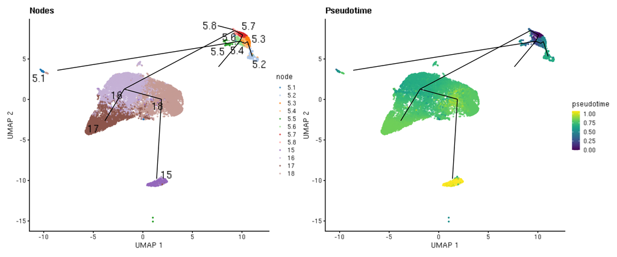

```r
by_node = aggregateAcrossCells(
  merged, ids = merged$node,
  use.assay.type = if ("reconstructed" %in% assayNames(merged)) "reconstructed" else "logcounts")

edges_umap = reportEdges(by_node, mst = pseudo$mst, clusters = NULL,
                         use.dimred = "UMAP")

p_node = plotUMAP(merged, colour_by = "node", text_by = "node", point_size = .5) +
  geom_line(data = edges_umap, mapping = aes(x = UMAP1, y = UMAP2, group = edge)) +
  ggtitle("Nodes")
p_pt = plotUMAP(merged, colour_by = "pseudotime", point_size = .5) +
  geom_line(data = edges_umap, mapping = aes(x = UMAP1, y = UMAP2, group = edge)) +
  ggtitle("Pseudotime")

p_node | p_pt
```

```r
ggsave(p_node | p_pt, file = paste0(results_dir, "/tscan_trajectory_umap.png"),
       width = 12, height = 5)
```

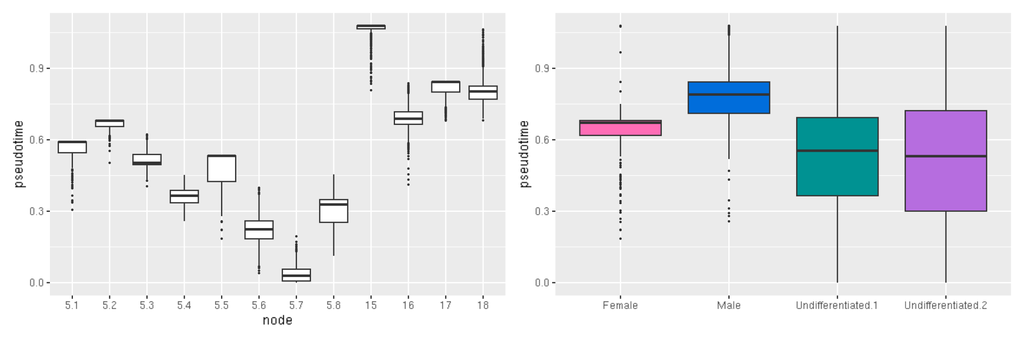

```r
pt_df = as.data.frame(colData(merged))

p_box_node = ggplot(pt_df, aes(x = node, y = pseudotime)) +
  geom_boxplot(outlier.size = .3) +
  xlab("node") + ylab("pseudotime")
p_box_lib = ggplot(pt_df, aes(x = library, y = pseudotime, fill = library)) +
  geom_boxplot(outlier.size = .3) +
  scale_fill_manual(values = lib_cols) +
  xlab(NULL) + ylab("pseudotime") +
  theme(legend.position = "none")

p_box_node | p_box_lib
```

```r
ggsave(p_box_node | p_box_lib, file = paste0(results_dir, "/tscan_pseudotime_by_node.png"),
       width = 12, height = 4)
```

## Edge confidence

An MST always returns a tree. It connects every node whether or not the data supports the connection, so the shape on its own says nothing about how much of it is real.

Five columns describe each edge from a different direction.

| column | what it is | low | high |
| --- | --- | --- | --- |
| `length` | distance between the node centroids | nodes sit close together | nodes are far apart |
| `nn_rank_1`, `nn_rank_2` | each node’s place in the other’s distance-ordered list | 1 and 1: mutual nearest neighbors | the edge reaches past nearer nodes |
| `separation` | centroid distance in within-node standard deviations, measured along the line joining them | under 1: one continuous population | two distinguishable groups |
| `pct_of_cut` | length as a percentage of the outgroup threshold | the edge survives outgroup splitting | over 100: outgroup splitting removes it |
| `frequency` | percentage of subsampled trees holding the edge | another sample would not have drawn it | drawn whatever the sample |

`frequency` comes from drawing `edge_boot_cells` cells from each node `edge_boot` times, with replacement, recomputing the centroids and rebuilding the tree. The count is fixed per node rather than proportional. A node of 5,000 cells has a centroid so precisely estimated that dropping a fifth of them moves it almost not at all, so a proportional subsample returns close to 100 percent for every edge including the arbitrary ones. Replacement matters for the small nodes: drawn without it, a node holding fewer cells than `edge_boot_cells` is taken whole every time and its centroid cannot move. Read it as a stress test rather than as a p-value.

A low `separation` is expected between consecutive waypoints on a trajectory. It is the reading to question where the two nodes carry annotations for distinct cell types. Combined with the ranks it separates cases that look alike on the figure.

| `separation` | `nn_rank` | reading |
| --- | --- | --- |
| low | 1 and 1 | one continuous population, joined at its closest point |
| low | high | overlapping nodes, joined the long way round |
| high | 1 and 1 | two distinct groups with a genuine link between them |
| high | high | a long edge to a node that sits near nothing |

No column says whether a low `separation` means the annotation is wrong or the subclustering was cut too fine. That comes from the marker sets.

```r
edge_key = function(a, b) paste(pmin(a, b), pmax(a, b), sep = " -- ")

edge_tab = igraph::as_data_frame(pseudo$mst, what = "edges") %>%
  dplyr::rename(node_1 = from, node_2 = to) %>%
  dplyr::mutate(length = signif(weight, 3),
                key = edge_key(node_1, node_2)) %>%
  dplyr::select(node_1, node_2, key, length)

# The outgroup rule, reported whether or not it is switched on. With
# outgroup = TRUE, createClusterMST puts an artificial node 1.5 times the median
# edge length away from every real node. An edge longer than that is beaten by a
# pair of edges through the outgroup, and deleting the outgroup leaves the tree
# in pieces. The median is taken from the tree built without an outgroup, which
# is the reference the package itself uses.
og_cut = if (is.numeric(params$outgroup)) {
  as.numeric(params$outgroup)
} else {
  ref = if (!isTRUE(params$outgroup)) edge_tab$length else {
    m0 = try(TrajectoryUtils::createClusterMST(
               reducedDim(merged, "corrected"),
               clusters    = as.character(merged$node),
               dist.method = as.character(params$dist_method),
               mnn.k       = params$mnn_k, outgroup = FALSE), silent = TRUE)
    if (inherits(m0, "try-error")) NULL else
      igraph::as_data_frame(m0, what = "edges")$weight
  }
  if (length(ref) == 0) NA_real_ else 1.5 * stats::median(ref)
}

# under 100 the edge survives outgroup splitting, over 100 it is cut
edge_tab$pct_of_cut = if (is.na(og_cut)) NA_real_ else
  round(100 * edge_tab$length / og_cut)

# Two reads on each edge that need no threshold, both from the node centroids of
# the corrected space.
#
#   nn_rank_1   where node_2 sits in node_1's list of nodes ordered by distance
#   nn_rank_2   where node_1 sits in node_2's
#   separation  centroid distance in standard deviations of the within-node
#               spread, so 2 means the centroids sit 2 SD apart
#
# Both are Euclidean, which is what dist.method = "simple" uses. Under any other
# dist.method they describe the corrected space rather than the distances the
# tree was built from.
co_all = reducedDim(merged, "corrected")
nd_all = as.character(merged$node)
cnt    = table(nd_all)
cent   = rowsum(co_all, nd_all)[names(cnt), , drop = FALSE] / as.vector(cnt)

# Within-node spread measured along the line joining the two centroids, which is
# the only direction the edge is about. Pooling the spread over all dimensions
# instead inflates this badly in a PC space: variance decays steeply across the
# dimensions, so an average over all fifty understates the spread along the few
# that separate the nodes. On simulated PC-like data a true two standard
# deviation gap reads 11.8 that way and 1.95 this way.
edge_separation = function(a, b) {
  ia = which(nd_all == a); ib = which(nd_all == b)
  if (length(ia) < 2 || length(ib) < 2) return(NA_real_)
  d = cent[b, ] - cent[a, ]
  L = sqrt(sum(d^2))
  if (!is.finite(L) || L == 0) return(NA_real_)
  u  = d / L
  va = stats::var(as.vector(co_all[ia, , drop = FALSE] %*% u))
  vb = stats::var(as.vector(co_all[ib, , drop = FALSE] %*% u))
  L / sqrt((va + vb) / 2)
}

node_dist = as.matrix(dist(cent))
diag(node_dist) = Inf
node_rank = t(apply(node_dist, 1, rank, ties.method = "min"))

edge_tab$nn_rank_1 = node_rank[cbind(edge_tab$node_1, edge_tab$node_2)]
edge_tab$nn_rank_2 = node_rank[cbind(edge_tab$node_2, edge_tab$node_1)]
edge_tab$separation = round(
  mapply(edge_separation, edge_tab$node_1, edge_tab$node_2), 2)

n_boot = as.integer(params$edge_boot)
boot_ok = n_boot > 0

if (boot_ok) {
  co   = reducedDim(merged, "corrected")
  nd   = as.character(merged$node)
  by_node = split(seq_along(nd), nd)

  tally = table(unlist(lapply(seq_len(n_boot), function(i) {
    set.seed(1000 + i)
    # stratified, so no node can vanish and change the node set
    # with replacement: a draw without it takes a node of 100 or fewer cells
    # whole every time, so its centroid never moves and its edges read 100 by
    # construction. Drawing with replacement gives every node the same centroid
    # precision whatever its size.
    keep = unlist(lapply(by_node, function(ix)
      sample(ix, max(2L, as.integer(params$edge_boot_cells)), replace = TRUE)))
    m = try(TrajectoryUtils::createClusterMST(
              co[keep, , drop = FALSE], clusters = nd[keep],
              dist.method = as.character(params$dist_method),
              mnn.k = params$mnn_k, outgroup = params$outgroup),
            silent = TRUE)
    if (inherits(m, "try-error")) return(NULL)
    e = igraph::as_data_frame(m, what = "edges")
    unique(edge_key(e$from, e$to))
  })))

  n_done = n_boot
  edge_tab$frequency = round(100 * as.integer(tally[edge_tab$key]) / n_done)
  edge_tab$frequency[is.na(edge_tab$frequency)] = 0

  # edges the resampling drew that the full-data tree did not
  extra = setdiff(names(tally), edge_tab$key)
  extra_tab = if (length(extra) == 0) NULL else
    data.frame(edge = extra,
               frequency = round(100 * as.integer(tally[extra]) / n_done),
               stringsAsFactors = FALSE) %>%
      dplyr::filter(frequency >= 10) %>%
      dplyr::arrange(dplyr::desc(frequency))
} else {
  edge_tab$frequency = NA_integer_
  extra_tab = NULL
}

edge_tab = edge_tab %>%
  dplyr::select(node_1, node_2, length, nn_rank_1, nn_rank_2, separation,
                pct_of_cut, frequency) %>%
  dplyr::arrange(dplyr::desc(is.na(frequency)), frequency, length)

write.csv(edge_tab, file = paste0(results_dir, "/mst_edges.csv"),
          row.names = FALSE)

# eight narrow columns: no paging unless the tree is large, numbers right
# aligned, and horizontal scroll rather than wrapped headers
datatable(edge_tab, rownames = FALSE, class = "compact stripe hover",
          options = list(dom = if (nrow(edge_tab) > 25) "tp" else "t",
                         paging = nrow(edge_tab) > 25, pageLength = 25,
                         scrollX = TRUE, autoWidth = FALSE,
                         columnDefs = list(list(className = "dt-right",
                                                targets = 2:7))))
```

| node_1 | node_2 | length | nn_rank_1 | nn_rank_2 | separation | pct_of_cut | frequency |
| --- | --- | --- | --- | --- | --- | --- | --- |
| 5.5 | 5.6 | 0.349 | 1 | 5 | 3.08 | 126 | 49 |
| 5.1 | 5.6 | 0.407 | 1 | 6 | 5.52 | 147 | 49 |
| 5.4 | 5.6 | 0.181 | 2 | 1 | 2.88 | 66 | 59 |
| 15 | 18 | 0.276 | 1 | 3 | 5.4 | 100 | 69 |
| 5.2 | 5.3 | 0.178 | 1 | 2 | 3.76 | 64 | 93 |
| 5.8 | 16 | 0.337 | 2 | 4 | 8.79 | 122 | 99 |
| 5.3 | 5.4 | 0.138 | 1 | 1 | 3.74 | 50 | 100 |
| 16 | 18 | 0.138 | 1 | 1 | 3.13 | 50 | 100 |
| 16 | 17 | 0.178 | 2 | 1 | 3.25 | 64 | 100 |
| 5.6 | 5.7 | 0.184 | 3 | 1 | 3.59 | 67 | 100 |

[output cut: 1 more lines]

The least confident edge is 5.5 to 5.6, drawn in 49 percent of 100 trees built from 100 cells per node. 2 of 11 edges appear in under half of them, and 5 in all of them.

The outgroup threshold for this tree is 0.276, which is 1.5 times the median edge length. 4 of 11 edges are longer, the longest being 5.1 to 5.6 at 147 percent. Under outgroup = TRUE the tree is rebuilt with the artificial node present, so the pieces are not guaranteed to be this tree minus those edges.

2 of 11 edges join mutual nearest neighbors. 6 reach further than either node’s second nearest, the furthest being 5.1 to 5.6 at ranks 1 and 6. Every pair sits at least one standard deviation apart. The per-edge values are in mst_edges.csv.

```r
if (!is.null(extra_tab) && nrow(extra_tab) > 0)
  datatable(extra_tab, rownames = FALSE, options = list(dom = "t", paging = FALSE))
```

| edge | frequency |
| --- | --- |
| 5.5 -- 5.7 | 51 |
| 5.3 -- 5.6 | 41 |
| 5.1 -- 5.5 | 35 |
| 15 -- 16 | 31 |
| 5.1 -- 5.8 | 16 |

**5 edge(s) appear in at least 10 percent of the subsampled trees without appearing in the tree above.** Where a competing edge is drawn nearly as often as the one that was kept, the two are interchangeable and the tree picked one of them.

## Node graph

Pie charts give the library composition of each node, and the lower panel colors nodes by mean pseudotime.

Edge length on this figure is meaningful. The layout is weighted by the real distance between nodes, so a long edge means the two nodes are far apart in the corrected space. Those distances are the `length` column of `mst_edges.csv`. The reproduction is not exact, because a tree in fifty dimensions cannot always be drawn faithfully in two, but it is close to a uniform rescale rather than arbitrary. If the message about a failed layout appears above, the figure fell back to an unweighted layout and edge lengths mean nothing.

```r
sample_tally = pt_df %>%
  mutate(node = as.factor(node), library = as.factor(library)) %>%
  group_by(node, library, .drop = FALSE) %>%
  tally()

node_meta = sample_tally %>%
  tidyr::pivot_wider(names_from = library, values_from = n, values_fill = 0) %>%
  ungroup()
for (l in names(lib_cols)) if (!l %in% names(node_meta)) node_meta[[l]] = 0
node_meta = node_meta %>%
  mutate(totalCells = rowSums(across(all_of(names(lib_cols))))) %>%
  dplyr::rename(name = "node") %>%
  mutate(name = as.character(name))

mean_pseudo = pt_df %>%
  group_by(node) %>%
  summarise(mean_pseudo = mean(pseudotime, na.rm = TRUE), .groups = "drop") %>%
  dplyr::rename(name = "node") %>%
  mutate(name = as.character(name))

# Edge confidence onto the graph. igraph reports edges in a fixed order and
# as_tbl_graph preserves it, so the column is assigned positionally from the
# same edge list rather than matched back by name.
e_ig = igraph::as_data_frame(pseudo$mst, what = "edges") %>%
  dplyr::mutate(key = edge_key(from, to)) %>%
  dplyr::left_join(edge_tab %>%
                     dplyr::mutate(key = edge_key(node_1, node_2)) %>%
                     dplyr::select(key, frequency, pct_of_cut),
                   by = "key")

# frequency where the subsampling ran, because "drawn in 38 percent of
# subsampled trees" reads without the legend. Gain stays in the table either way.
use_freq  = boot_ok && !anyNA(e_ig$frequency)
e_ig$conf = if (use_freq) as.numeric(e_ig$frequency) else NA_real_
conf_fmt  = function(v) sprintf("%d%%", round(v))

gr = as_tbl_graph(pseudo$mst) %>%
  activate(nodes) %>%
  left_join(node_meta, by = "name") %>%
  left_join(mean_pseudo, by = "name") %>%
  activate(edges) %>%
  mutate(conf = e_ig$conf,
         cut_pct = as.numeric(e_ig$pct_of_cut))

# Layout by real distance. The stress layout ignores edge weights by default and
# draws every edge at roughly the same length, so the picture says nothing about
# how far apart nodes are. graphlayouts treats weights as similarities, not
# distances, so the reciprocal is what is passed: a long edge then has a weak
# pull and is drawn long. On test trees this reproduces the true edge lengths to
# a near-uniform scale factor, correlation 0.999. It also survives a tree split
# into components, which a distance-matrix layout does not.
layout_by_distance = function(graph, lengths) {
  w = as.numeric(lengths)
  w[!is.finite(w) | w <= 0] = min(w[is.finite(w) & w > 0], na.rm = TRUE) / 1000
  out = try(create_layout(graph, layout = "stress", weights = 1 / w), silent = TRUE)
  if (inherits(out, "try-error")) {
    message("distance-weighted layout failed; falling back to plain stress, ",
            "so edge lengths on the figure will not be meaningful")
    out = create_layout(graph, layout = "stress")
  }
  out
}

set.seed(1)
layout_data = layout_by_distance(gr, e_ig$weight)

# edge midpoints for the numeric labels, from the layout rather than through a
# ggraph label aesthetic, whose arguments vary between versions
e_ig$x = (layout_data$x[match(e_ig$from, layout_data$name)] +
          layout_data$x[match(e_ig$to,   layout_data$name)]) / 2
e_ig$y = (layout_data$y[match(e_ig$from, layout_data$name)] +
          layout_data$y[match(e_ig$to,   layout_data$name)]) / 2
stopifnot(!anyNA(e_ig$x))


# A distance-faithful layout packs tightly related nodes close together, so the
# glyphs have to be sized to the layout rather than fixed. Radius comes from the
# closest pair, with a floor so a very tight pair does not shrink everything to
# nothing. Overlap that remains is informative: those nodes really are that close.
lay_d = as.matrix(dist(as.matrix(layout_data[, c("x", "y")])))
diag(lay_d) = Inf
lay_span = max(diff(range(layout_data$x)), diff(range(layout_data$y)))
layout_data$r = max(min(lay_d) * 0.42, lay_span * 0.012)
pt_size = max(2, min(9, 55 * min(lay_d) / lay_span))

# Confidence is carried by edge color alone. Encoding it as width and color and
# a printed number as well cost two more things to read for no more information.
# The values are in mst_edges.csv and graph_edge_labels puts them back on.
# Edge colour is the length as a percentage of the outgroup threshold, not the
# subsampling frequency. Frequency reads 100 for an edge the tree was forced to
# draw, because a node that belongs nowhere is attached to the same place in
# every resample. The threshold says how long the edge is, which that cannot
# hide. Blue is short, red is past the threshold; the numbers are in
# mst_edges.csv along with the frequency.
use_cut  = !all(is.na(e_ig$pct_of_cut))
edge_aes = list(
  if (use_cut) geom_edge_link(aes(edge_colour = cut_pct), edge_width = 1.1)
    else geom_edge_link(edge_colour = "grey55", edge_width = 1.1),
  if (use_cut) scale_edge_colour_gradient2(low = "#2166ac", mid = "#bdbdbd",
                  high = "#b2182b", midpoint = 100,
                  name = "% of the outgroup\nthreshold") else NULL)

node_lab = geom_text_repel(data = layout_data, aes(x, y, label = name),
                           inherit.aes = FALSE, size = 2.6, colour = "grey20",
                           min.segment.length = 0, segment.size = .2,
                           segment.colour = "grey60", box.padding = .45,
                           max.overlaps = Inf, seed = 1)

edge_lab = if (isTRUE(params$graph_edge_labels))
  geom_label(data = e_ig, aes(x, y, label = conf_fmt(conf)), inherit.aes = FALSE,
             size = 2.0, colour = "grey15", fill = "white",
             label.padding = unit(.1, "lines"), label.size = NA) else NULL

gr_pie =
  ggraph(layout_data) +
  edge_aes +
  geom_scatterpie(aes(x, y, r = r), cols = names(lib_cols), data = layout_data,
                  colour = NA) +
  scale_fill_manual(name = "Library", values = lib_cols) +
  node_lab + edge_lab +
  coord_fixed() +
  theme_void(base_size = 9)

gr_pseudo =
  ggraph(layout_data) +
  edge_aes +
  geom_node_point(aes(color = mean_pseudo), size = max(6, pt_size * 1.6)) +
  scale_color_viridis_c(name = "mean pseudotime") +
  node_lab + edge_lab +
  coord_fixed() +
  theme_void(base_size = 9)

p_node_graph = (gr_pie / gr_pseudo) +
  patchwork::plot_layout(guides = "collect") +
  patchwork::plot_annotation(tag_levels = "A") &
  theme(legend.position = "right", legend.box = "vertical",
        legend.key.size = unit(.4, "cm"),
        legend.title = element_text(size = 8),
        legend.text  = element_text(size = 7),
        plot.tag     = element_text(size = 11, face = "bold"))

p_node_graph
```

[figure not shown]

```r
# saved explicitly rather than relying on the last plot, and in both formats:
# pdf for figure assembly, png for slides and email
ggsave(p_node_graph, file = paste0(results_dir, "/tscan_node_graph.pdf"),
       width = 7, height = 7)
ggsave(p_node_graph, file = paste0(results_dir, "/tscan_node_graph.png"),
       width = 7, height = 7, dpi = 300)
```

## Which node reached for which

Each pair is drawn twice, once in each direction. An arrow from A to B is colored by where B sits in A’s list of nodes ordered by distance, so an edge blue in both directions joins mutual nearest neighbors. An arrow that is blue one way and red the other is a node reaching for a partner that is not reaching back: the tail node had to attach somewhere and this was its best option, while the head node has many closer neighbors.

This is the reading the edge frequency cannot give. A forced attachment is drawn in every resample, so it scores 100 percent there while showing red here.

```r
# Two directed edges per pair, each colored by how the node it points to ranks
# among the neighbors of the node it leaves. Node positions are taken from the
# layout above so the two figures can be read against each other.
dir_edges = dplyr::bind_rows(
  edge_tab %>% dplyr::transmute(from = node_1, to = node_2, rank = nn_rank_1),
  edge_tab %>% dplyr::transmute(from = node_2, to = node_1, rank = nn_rank_2))

gr_dir  = tidygraph::tbl_graph(
  nodes = data.frame(name = layout_data$name, stringsAsFactors = FALSE),
  edges = dir_edges, directed = TRUE)
lay_dir = create_layout(gr_dir, layout = "manual", x = layout_data$x, y = layout_data$y)

g_rank = ggraph(lay_dir) +
  geom_edge_fan(aes(edge_colour = rank),
                arrow = grid::arrow(length = unit(1.8, "mm"), type = "closed"),
                start_cap = circle(2, "mm"), end_cap = circle(2.4, "mm"),
                edge_width = .8) +
  scale_edge_colour_gradient(low = "#2166ac", high = "#b2182b", trans = "log10",
                             name = "rank of the node\nthe arrow points to") +
  geom_node_point(size = max(1.5, pt_size * .5), colour = "grey30") +
  geom_node_text(aes(label = name), size = 2.1, repel = TRUE) +
  coord_fixed() +
  theme_void(base_size = 9) +
  theme(legend.position = "right", legend.key.size = unit(.4, "cm"),
        legend.title = element_text(size = 8), legend.text = element_text(size = 7))

g_rank
```

[figure not shown]

```r
ggsave(g_rank, file = paste0(results_dir, "/tscan_node_graph_ranks.png"),
       width = 9, height = 8, dpi = 300)
ggsave(g_rank, file = paste0(results_dir, "/tscan_node_graph_ranks.pdf"),
       width = 9, height = 8)
```

## Marker sets on the tree

The same tree, once per germ cell marker set. Color is the set’s mean log expression scaled to its own maximum, so the panels show where each program sits rather than how the programs compare with one another. Size is the percentage of cells in the node detecting the set.

Each panel title carries the set’s absolute maximum. A panel whose maximum is near zero is showing noise stretched across the full color range, so read the title before the colors. The unscaled values are in `root_marker_set_scores.csv`.

```r
graph_sets = trimws(strsplit(as.character(params$graph_marker_sets), ",")[[1]])
graph_sets = intersect(graph_sets[nzchar(graph_sets)], unique(set_scores$set))

set_panel = function(s) {
  sc = set_scores %>% dplyr::filter(set == s)
  mx = suppressWarnings(max(sc$mean_logexpr, na.rm = TRUE))
  ld = layout_data
  ld$rel = if (is.finite(mx) && mx > 0)
    sc$mean_logexpr[match(ld$name, as.character(sc$node))] / mx else NA_real_
  ld$pct = sc$pct_detected[match(ld$name, as.character(sc$node))]

  ggraph(ld) +
    edge_aes +
    geom_node_point(aes(colour = rel, size = pct)) +
    scale_colour_viridis_c(name = "expression, relative\nto the set maximum",
                           limits = c(0, 1)) +
    scale_size_continuous(name = "% of cells detecting",
                          range = c(1.5, 7), limits = c(0, 100)) +
    geom_text_repel(data = ld, aes(x, y, label = name), inherit.aes = FALSE,
                    size = 2.2, colour = "grey25", min.segment.length = 0,
                    segment.size = .2, segment.colour = "grey70",
                    box.padding = .35, max.overlaps = Inf, seed = 1) +
    coord_fixed() +
    theme_void(base_size = 8) +
    ggtitle(sprintf("%s  (max %.2f)", s, mx)) +
    theme(plot.title = element_text(size = 8, hjust = .5))
}

if (length(graph_sets) > 0) {
  p_set_graph = patchwork::wrap_plots(lapply(graph_sets, set_panel),
                                      ncol = min(2, length(graph_sets))) +
    patchwork::plot_layout(guides = "collect") &
    theme(legend.position = "right", legend.box = "vertical",
          legend.key.size = unit(.35, "cm"),
          legend.title = element_text(size = 7),
          legend.text  = element_text(size = 6))

  print(p_set_graph)
  ggsave(p_set_graph, file = paste0(results_dir, "/tscan_node_graph_marker_sets.png"),
         width = 11, height = 9, dpi = 300)
  ggsave(p_set_graph, file = paste0(results_dir, "/tscan_node_graph_marker_sets.pdf"),
         width = 11, height = 9)
}
```

[figure not shown]

## What the ordering tracks

```r
lib_r2 = if (dplyr::n_distinct(pt_df$library) > 1)
  summary(lm(pseudotime ~ library, data = pt_df))$r.squared else NA_real_
stage_r2 = if (dplyr::n_distinct(pt_df$stage) > 1)
  summary(lm(pseudotime ~ stage, data = pt_df))$r.squared else NA_real_
```

Library explains 36.9% of the variance in pseudotime, and stage explains 34.6%.

# Pseudotime-associated genes

Genes changing along each path, tested on uncorrected log counts. All genes at FDR < 0.01 are written to `tscan_pseudotime_genes.csv`.

```r
test_file     = paste0(Robject_out_dir, "/tscan_test_pseudotime.Rds")
test_sig_file = paste0(Robject_out_dir, "/tscan_test_pseudotime_signature.txt")

pseudo_mat = pathStat(pseudo$ordering)

if (file.exists(test_file) && file.exists(test_sig_file) &&
    identical(readLines(test_sig_file, warn = FALSE)[1], pseudo_sig)) {
  test_pseudo = readRDS(test_file)
} else {
  test_pseudo = TSCAN::testPseudotime(combined, pseudotime = pseudo_mat)
  saveRDS(test_pseudo, file = test_file)
  writeLines(pseudo_sig, test_sig_file)
}

path_genes = dplyr::bind_rows(lapply(seq_along(test_pseudo), function(i) {
  as.data.frame(test_pseudo[[i]]) %>%
    tibble::rownames_to_column("Gene") %>%
    dplyr::mutate(Path = names(test_pseudo)[i])
})) %>%
  dplyr::filter(FDR < params$fdr_cut) %>%
  dplyr::left_join(gene_description, by = "Gene") %>%
  dplyr::mutate(Direction = ifelse(logFC > 0, "up", "down")) %>%
  dplyr::select(Path, Direction, Gene, WangGeneID, description, logFC, p.value, FDR) %>%
  dplyr::arrange(Path, FDR)

write.csv(path_genes, file = paste0(results_dir, "/tscan_pseudotime_genes.csv"),
          row.names = FALSE)

datatable(path_genes %>% mutate(across(c(logFC, p.value, FDR), ~signif(., 3))),
          filter = "top", rownames = FALSE)
```

| Path | Direction | Gene | WangGeneID | description | logFC | p.value | FDR |
| --- | --- | --- | --- | --- | --- | --- | --- |
| 15 | down | CMPK1 | CMPK1 | cytidine/uridine monophosphate kinase 1 | -0.156 | 0 | 0 |
| 15 | up | RPS17 | RPS17 | ribosomal protein S17 | 0.702 | 0 | 0 |
| 15 | down | LOC116950069 | LOC116950069 | uncharacterized LOC116950069, transcript variant X3 | -0.784 | 0 | 0 |
| 15 | down | LOC116941712 | OAZ2 | ornithine decarboxylase antizyme 2-like | -0.827 | 0 | 0 |
| 15 | up | CCNB2 | CCNB2 | cyclin B2 | 3.33 | 0 | 0 |
| 15 | down | RPL4 | RPL4 | ribosomal protein L4 | -0.0626 | 0 | 0 |
| 15 | up | KIF23 | KIF23 | kinesin family member 23, transcript variant X1 | 0.604 | 0 | 0 |
| 15 | down | FDPS | FDPS | farnesyl diphosphate synthase | -1.09 | 0 | 0 |
| 15 | down | LOC116945539 | TUBA8 | tubulin alpha-8 chain-like | -0.27 | 0 | 0 |
| 15 | up | LOC116947166 | CDK2.1 | cyclin-dependent kinase 2-like | 2.37 | 0 | 0 |

[output cut: 33151 more lines]

33,161 gene-path results at FDR < 0.01.

## Heatmaps

The 25 most significant genes in each direction along each path.

```r
top_by_path = path_genes %>%
  dplyr::mutate(set = paste0(Path, ".", Direction)) %>%
  dplyr::group_by(set) %>%
  dplyr::arrange(FDR, desc(abs(logFC)), .by_group = TRUE) %>%
  dplyr::slice_head(n = 25) %>%
  dplyr::summarise(Gene = list(Gene), .groups = "drop") %>%
  tibble::deframe()

# the heatmap's pseudotime bar uses a fixed 0 to 1 color scale
pt_range = range(combined$pseudotime, na.rm = TRUE)
combined$pseudotime_scaled = (combined$pseudotime - pt_range[1]) / diff(pt_range)

heatmaps = list()
for (s in names(top_by_path)) {
  gene_ids    = top_by_path[[s]]
  gene_labels = gene_description$WangGeneID[match(gene_ids, gene_description$Gene)]
  gene_labels = ifelse(is.na(gene_labels), gene_ids, gene_labels)

  path_name   = sub("\\.(up|down)$", "", s)
  cell_subset = rownames(pseudo_mat)[!is.na(pseudo_mat[, path_name])]

  heatmaps[[s]] = plot_pseudotime_heatmap(combined, gene_ids, gene_labels,
                                          cell_subset,
                                          pseudotime_column = "pseudotime_scaled")
}
```

```r
for (s in names(heatmaps)) {
  # The heading starts with a word. Pandoc builds anchor ids by dropping
  # everything before the first letter, so a heading of "15.up" becomes the id
  # "up", every path collides, and the table of contents shows a column of
  # "up" and "down" with no path named.
  cat("\n\n### Path ", sub("[.](up|down)$", "", s), ", ",
      sub("^.*[.]", "", s), "\n\n", sep = "")

  # guides = "collect" is what plot_pseudotime_heatmap sets. Rebuilding the
  # patchwork here to change the heights drops it, which leaves the pseudotime
  # legend to render inside a strip 3 percent of the figure height.
  hp = (heatmaps[[s]][[1]] / heatmaps[[s]][[2]]) +
    plot_layout(heights = c(0.03, 1), guides = "collect")
  f  = paste0(results_dir, "/tscan_heatmap_",
              gsub("[^A-Za-z0-9]+", "_", s), ".png")
  ggsave(hp, file = f, width = 7, height = 5, dpi = 600)

  # The file is written first and then referenced as markdown, rather than
  # printed to the knitr device. In an asis chunk knitr interleaves device
  # output with cat output, and a figure can land under the wrong heading or be
  # dropped. A markdown link is part of the text stream, so the pairing is
  # fixed. Pandoc embeds the file, so the html stays self-contained.
  cat("![](", f, ")\n\n", sep = "")
}
```

### Path 15, down

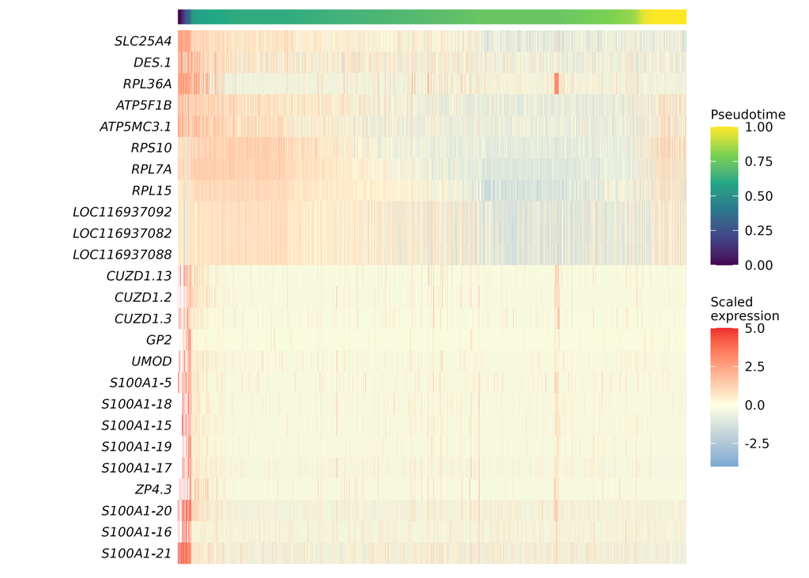

### Path 15, up

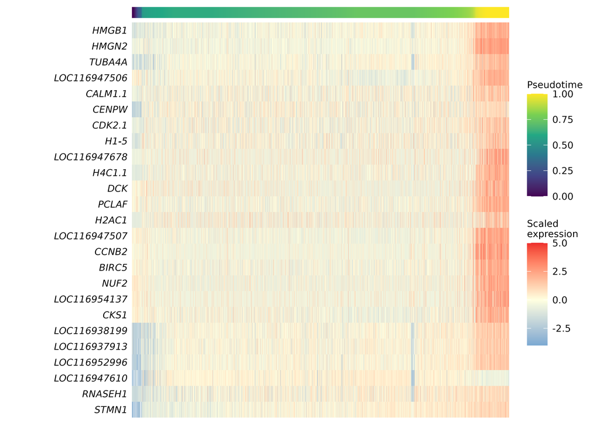

### Path 17, down

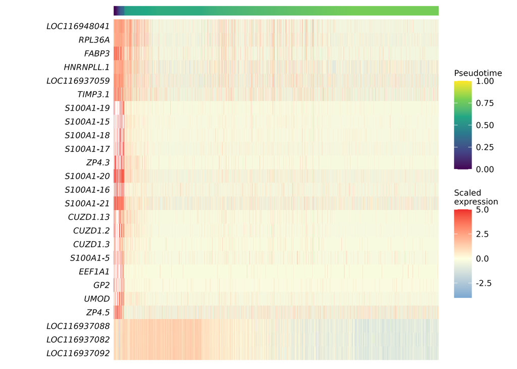

### Path 17, up

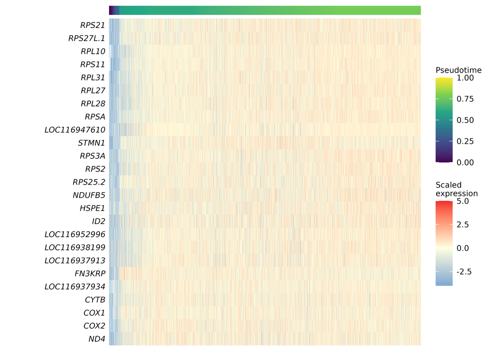

### Path 5.1, down

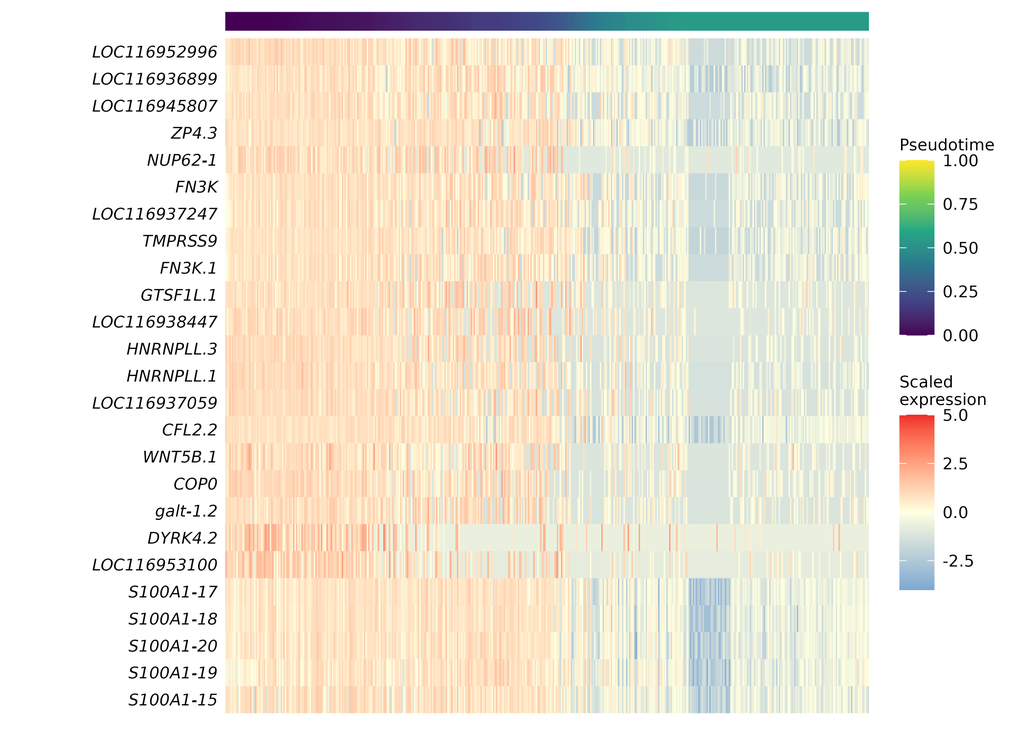

### Path 5.1, up

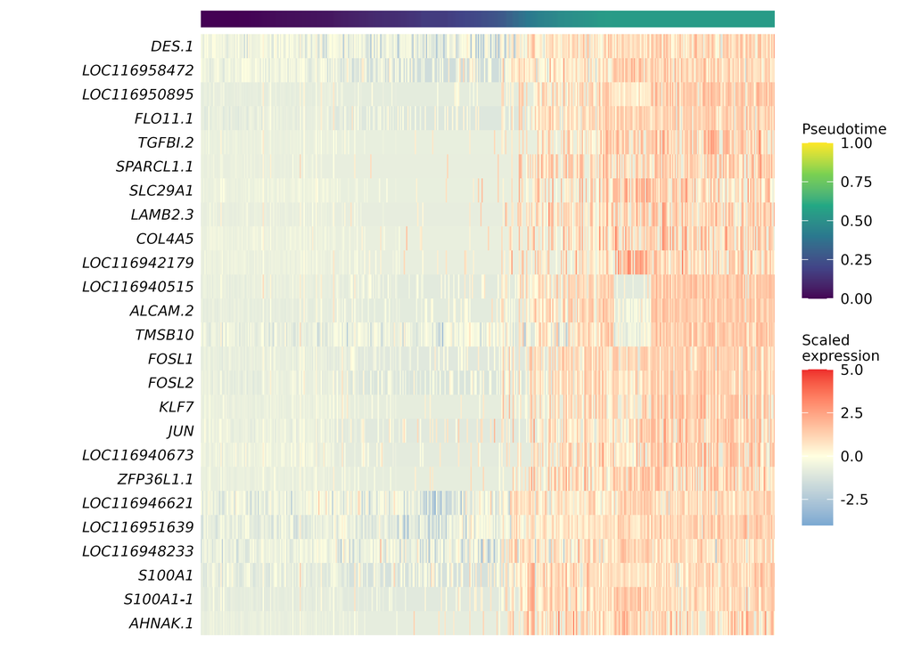

### Path 5.2, down

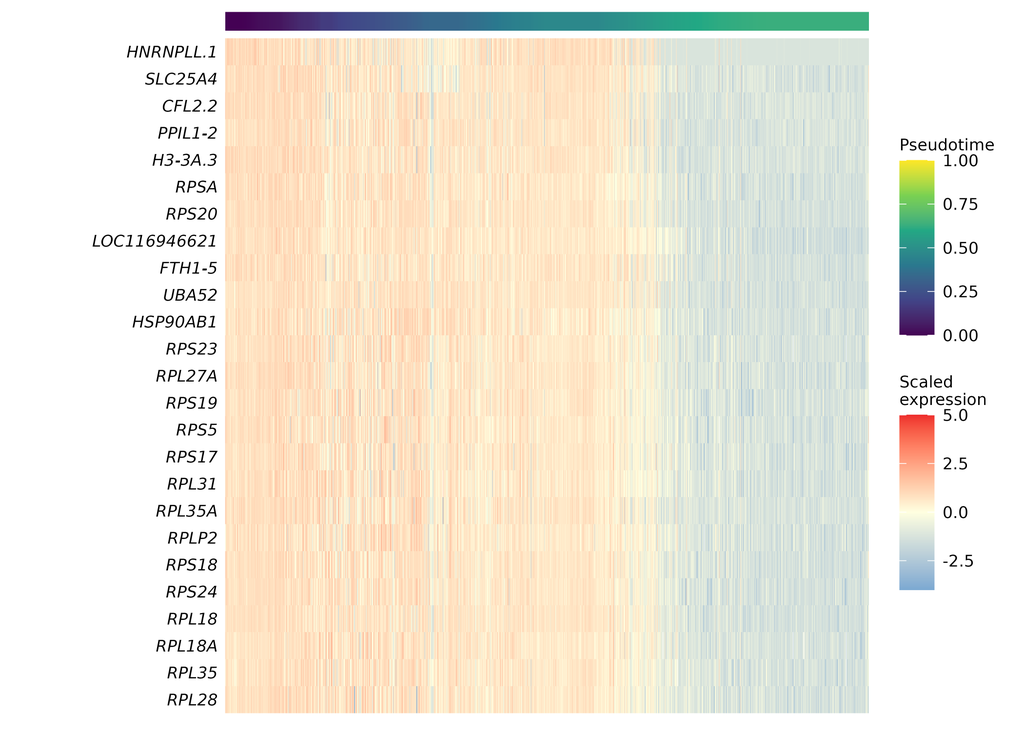

### Path 5.2, up

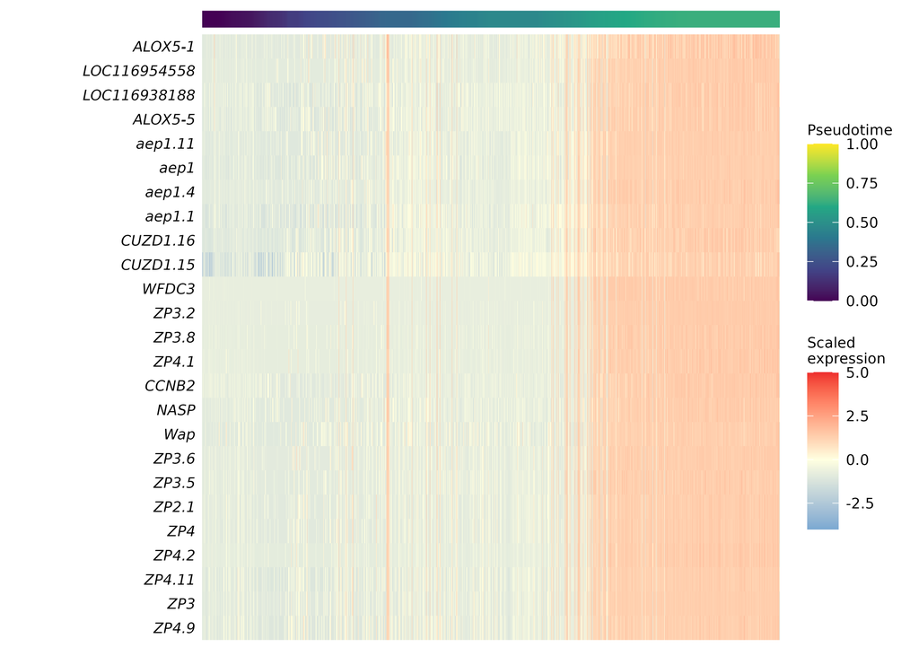

### Path 5.5, down

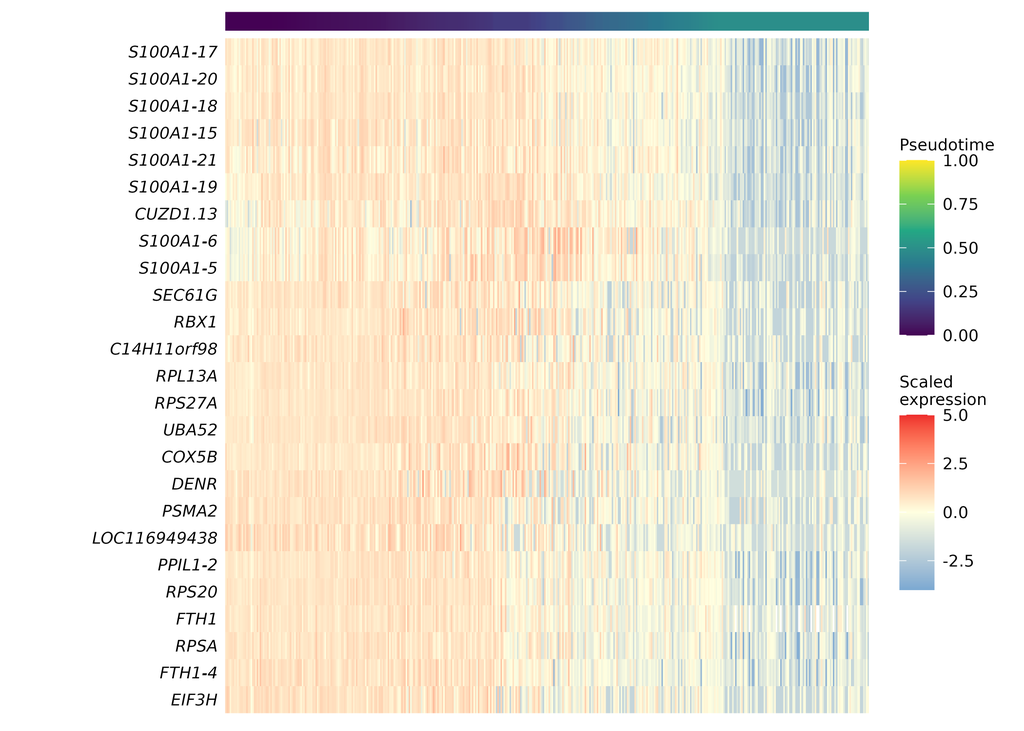

### Path 5.5, up

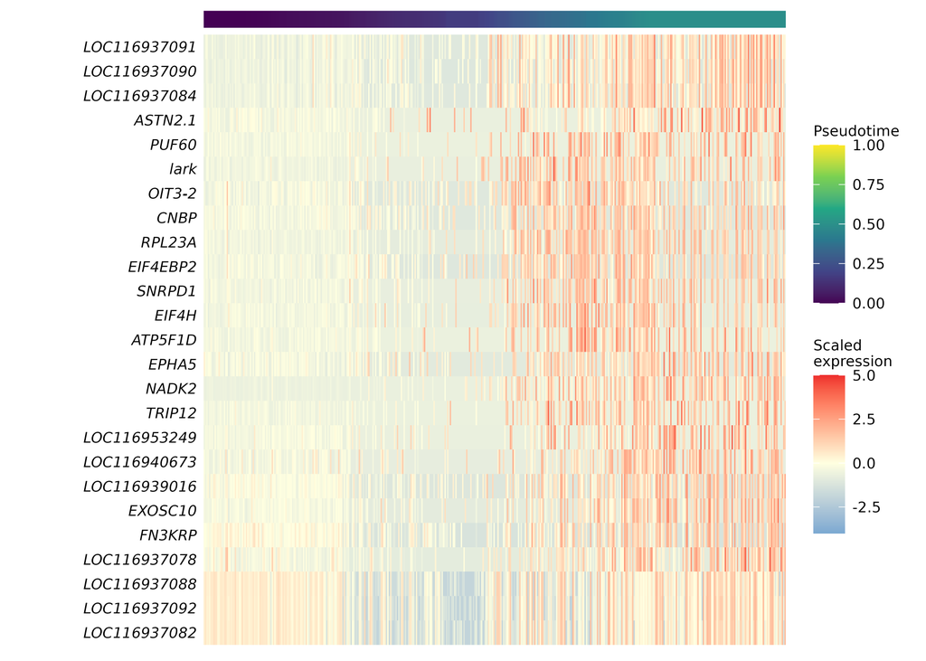

## GO enrichment of pseudotime-associated genes

GO enrichment for each path and direction, against every gene in the data. Terms with p < 0.05 are shown and written to `tscan_pseudotime_GO_pvalues.csv`.

```r
path_go = run_go_enrichment(
  gaf              = gaf,
  gene_description = gene_description,
  go_names         = go_names,
  test_genes       = path_genes %>%
                       dplyr::transmute(Gene, set = paste0(Path, ".", Direction)) %>%
                       dplyr::distinct(),
  background_n     = nrow(combined),
  group2_label     = "Path",
  ngroup2_label    = "nPathGenes",
  overlaps_file    = paste0(results_dir, "/tscan_pseudotime_GO_overlaps.csv"),
  pvals_file       = paste0(results_dir, "/tscan_pseudotime_GO_pvalues.csv"),
  pval_filter      = params$go_pval)

datatable(path_go %>% mutate(across(where(is.numeric), ~signif(., 3))),
          filter = "top", rownames = FALSE)
```

| GOID | GOName | nGOTermGenes | Path | nPathGenes | nSharedGenes | Pval | FDR |
| --- | --- | --- | --- | --- | --- | --- | --- |
| GO:0000027 | ribosomal large subunit assembly | 16 | 15.up | 2450 | 6 | 0.00566 | 0.0486 |
| GO:0000027 | ribosomal large subunit assembly | 16 | 17.up | 1350 | 7 | 2.24e-05 | 0.000759 |
| GO:0000027 | ribosomal large subunit assembly | 16 | 5.1.up | 896 | 5 | 0.000335 | 0.00768 |
| GO:0000027 | ribosomal large subunit assembly | 16 | 5.2.up | 3730 | 7 | 0.0111 | 0.0779 |
| GO:0000027 | ribosomal large subunit assembly | 16 | 5.5.down | 2280 | 5 | 0.0197 | 0.121 |
| GO:0000028 | ribosomal small subunit assembly | 15 | 15.up | 2450 | 11 | 2.87e-08 | 1.62e-06 |
| GO:0000028 | ribosomal small subunit assembly | 15 | 17.up | 1350 | 13 | 1.52e-14 | 2.15e-12 |
| GO:0000028 | ribosomal small subunit assembly | 15 | 5.1.up | 896 | 7 | 8.86e-07 | 4.7e-05 |
| GO:0000028 | ribosomal small subunit assembly | 15 | 5.2.down | 5020 | 10 | 0.000366 | 0.00956 |
| GO:0000028 | ribosomal small subunit assembly | 15 | 5.5.down | 2280 | 12 | 5.16e-10 | 2.43e-08 |

[output cut: 649 more lines]

# Export

```r
cell_out = pt_df %>%
  tibble::rownames_to_column("barcode") %>%
  dplyr::select(barcode, library, stage, final_label, cell_type, node, pseudotime)

umap = reducedDim(merged, "UMAP")
cell_out$UMAP1 = umap[, 1]
cell_out$UMAP2 = umap[, 2]

write.csv(cell_out, file = paste0(results_dir, "/pseudotime_per_cell.csv"),
          row.names = FALSE)
```

Per-cell pseudotime is written to `pseudotime_per_cell.csv`.

## Everything written by this document

Built by listing the results directory and looking each file up, rather than by keeping a list by hand. A file with no description, or a description with no file, is reported below instead of passing unnoticed.

```r
file_notes = c(
  "pseudotime_per_cell.csv" = "One row per cell: library, stage, cluster, node, pseudotime and UMAP coordinates. The file every other document reads.",
  "cluster_composition.csv" = "Cells per cluster, split by cell type and library, before any subclustering.",
  "node_composition.csv"    = "Cells per node, split by library.",
  "root_marker_set_scores.csv" = "Each node scored on the germ cell marker sets. The root rule is applied to this table.",
  "mst_edges.csv"           = "Every edge of the tree with four reads on it: its length in the corrected space, where each node ranks in the other's neighbor list, the centroid distance in standard deviations of the within-node spread, its length as a percentage of the outgroup threshold, and the percentage of subsampled trees containing it.",
  "node_identity_scores.csv" = "Each node against all marker sets, somatic ones included, with a contained_in flag where one set sits inside another.",
  "node_marker_expression.csv" = "The per-gene values behind the node identity plot: percent expressing and mean log expression for every marker gene in every node.",
  "subcluster_marker_genes.csv" = "Markers of each node against the other nodes of this lineage. A within-lineage comparison, so it cannot see programs the nodes share.",
  "subcluster_marker_GO_overlaps.csv" = "Genes shared between each node marker list and each GO term.",
  "subcluster_marker_GO_pvalues.csv"  = "Enrichment of GO terms in each node marker list.",
  "tscan_pseudotime_genes.csv"        = "Genes whose expression changes along the ordering.",
  "tscan_pseudotime_GO_overlaps.csv"  = "Genes shared between the pseudotime gene list and each GO term.",
  "tscan_pseudotime_GO_pvalues.csv"   = "Enrichment of GO terms among the pseudotime-associated genes.",
  "somatic_check_set_scores.csv"      = "Every node of the annotated run scored on all marker sets, computed before any cell is removed. Only written when drop_annotations names something.",
  "annotated_run_depth_and_technical.csv" = "Depth, genes detected, percent mitochondrial, rRNA and ribosomal per node of the annotated run. Only written when drop_annotations names something.",
  "somatic_check_gene_expression.csv" = "The per-gene values behind the somatic check bubble plot. Only written when drop_annotations names something.",
  "node_depth_and_technical.csv"      = "The same four measures for this run's nodes.",
  "subcluster_depth_tests.csv"        = "Kruskal-Wallis of each measure across the subclusters, with the fold range in median depth.",
  "subcluster_downsample_check.csv"   = "Subclusters recomputed after downsampling every cell to a common depth, with the ARI against the original. A low ARI means the split was depth.",
  "subcluster_stability.csv"          = "The ARI sweep over sub_k_range. Only written when subclusters are recomputed.",
  "subcluster_k_choice.csv"           = "Each candidate k with the subcluster count it returned and its ARI. Only written when subclusters are recomputed.",
  "subcluster_annotation_map.csv"     = "Every old-new subcluster pair with shared cell counts and Jaccard. Only written when subclusters are recomputed.",
  "subcluster_overlap_grid.csv"       = "The same overlap as percentages of the new subcluster, the old one and the union. Only written when subclusters are recomputed.",
  "tscan_trajectory_umap.png"         = "UMAP colored by node and by pseudotime, with the tree drawn over it.",
  "tscan_node_graph.png"              = "The tree itself: library composition per node as pie charts, and nodes colored by mean pseudotime.",
  "tscan_node_graph_ranks.png" = "The tree with two arrows per pair, each colored by how the node it points to ranks among the neighbors of the node it leaves.",
  "tscan_node_graph_ranks.pdf" = "The rank graph as a vector file.",
  "tscan_node_graph.pdf"              = "The node graph as a vector file, for figure assembly.",
  "tscan_node_graph_marker_sets.png"  = "The same tree once per germ marker set, colored by expression relative to that set's maximum and sized by percent of cells detecting it.",
  "tscan_node_graph_marker_sets.pdf"  = "The marker set panels as a vector file.",
  "tscan_pseudotime_by_node.png"      = "Pseudotime distribution per node and per library.",
  "node_identity_scores.png"          = "Marker expression per node, one dot per gene.",
  "somatic_check_bubble.png"          = "Marker expression per node of the annotated run, one dot per gene. Only written when drop_annotations names something.",
  "annotated_run_depth_and_technical.png" = "Depth and technical content per node of the annotated run. Only written when drop_annotations names something.",
  "node_depth_and_technical.png"      = "Depth and technical content per node of this run.",
  "subcluster_overlap.png"            = "Old against new subclusters as percentages, three panels. Only written when subclusters are recomputed.")

in_dir  = sort(setdiff(list.files(results_dir), "Robjects"))
in_dir  = in_dir[!grepl("^tscan_heatmap_", in_dir)]

# The table describes what this document writes. The results directory also
# holds whatever earlier runs left behind, and those are named below rather
# than given rows with no description.
on_disk = intersect(names(file_notes), in_dir)
unknown = setdiff(in_dir, names(file_notes))
missing = setdiff(names(file_notes), in_dir)

export_tab = data.frame(
  file = on_disk,
  size = sapply(file.path(results_dir, on_disk),
                function(f) format(structure(file.size(f), class = "object_size"),
                                   units = "auto")),
  what = unname(file_notes[on_disk]),
  stringsAsFactors = FALSE)

datatable(export_tab, rownames = FALSE, escape = FALSE,
          options = list(pageLength = 40, dom = "tp",
                         columnDefs = list(list(width = "260px", targets = 0))))
```

| file | size | what |
| --- | --- | --- |
| pseudotime_per_cell.csv | 2.3 Mb | One row per cell: library, stage, cluster, node, pseudotime and UMAP coordinates. The file every other document reads. |
| cluster_composition.csv | 325 bytes | Cells per cluster, split by cell type and library, before any subclustering. |
| node_composition.csv | 340 bytes | Cells per node, split by library. |
| root_marker_set_scores.csv | 1.1 Kb | Each node scored on the germ cell marker sets. The root rule is applied to this table. |
| mst_edges.csv | 454 bytes | Every edge of the tree with four reads on it: its length in the corrected space, where each node ranks in the other's neighbor list, the centroid distance in standard deviations of the within-node spr… |
| node_identity_scores.csv | 10 Kb | Each node against all marker sets, somatic ones included, with a contained_in flag where one set sits inside another. |
| node_marker_expression.csv | 68.4 Kb | The per-gene values behind the node identity plot: percent expressing and mean log expression for every marker gene in every node. |
| subcluster_marker_genes.csv | 118.5 Kb | Markers of each node against the other nodes of this lineage. A within-lineage comparison, so it cannot see programs the nodes share. |
| subcluster_marker_GO_overlaps.csv | 423.7 Kb | Genes shared between each node marker list and each GO term. |
| subcluster_marker_GO_pvalues.csv | 12.3 Kb | Enrichment of GO terms in each node marker list. |

[output cut: 26 more lines]

4 file(s) in the directory are not written by this document and are left out of the table: pseudotime_per_cell_annotated.csv, pseudotime_per_cell_with_12t.csv, pseudotime_vs_technical.csv, pseudotime_vs_technical.png. Either an earlier version wrote them, or they are new and need a line in file_notes.

Cached intermediates are in /mnt/ufs18/rs-013/bioinformaticsCore/projects/chong_davidson/BCC125_sea_lamprey_scRNA/results/20260813_pseudotime_tscan_all/Robjects and are not listed. They are rebuilt when their signature changes.

# Summary

```r
summary_tbl = data.frame(
  quantity = c("lineage", "clusters", "cells", "libraries kept", "nodes", "root",
               "paths", "variance in pseudotime explained by library",
               paste0("gene-path results at FDR < ", params$fdr_cut)),
  value = c(lineage,
            paste(clusters, collapse = ", "),
            format(ncol(merged), big.mark = ","),
            paste(objs$kept_batches, collapse = ", "),
            as.character(nlevels(merged$node)),
            root,
            as.character(n_paths),
            if (is.na(lib_r2)) "one library" else paste0(round(100 * lib_r2, 1), "%"),
            format(nrow(path_genes), big.mark = ",")),
  stringsAsFactors = FALSE)

datatable(summary_tbl, rownames = FALSE, colnames = c("", ""),
          options = list(dom = "t", ordering = FALSE, paging = FALSE))
```

| lineage | all |
| --- | --- |
| clusters | 5, 15, 16, 17, 18 |
| cells | 17,263 |
| libraries kept | TF_C00004337, TM_C00004374, UND1_C00004336, UND2_C00004362 |
| nodes | 12 |
| root | 5.7 |
| paths | 5 |
| variance in pseudotime explained by library | 36.9% |
| gene-path results at FDR &lt; 0.01 | 33,161 |